# TMS WM Analysis

2025-1-29

## Packages

```r
# import packages
library(lme4) # mixed models
library(dplyr) # dataframe manipulation
library(readr) # reading in the data
library(emmeans) # likelihood ratio testing
```

```r
library(purrr) # for map()
library(lattice) # for xyplot()
library(TAF) # setting up output file directory structure during model fitting
library(moments) # skewness for selecting between additive and multiplicative models of response times
library(stringr)


# If you get an error, you likely need to install the packages using the "install.package('insert-package-name-here')" command
```

## Notebook configurable settings

```r
# name the directories to read data from and write output to
input_version <- 9
output_version <- "programming"
program_type <- "long"
```

make an overall output directory (model summaries, stats, etc. will all go here)

```r
# setwd("..")
outputdir <- sprintf(
  "%s/../candidate-models/regression-models-%s", getwd(), output_version
)
```

```r
mkdir(outputdir)
```

## Loading Data

```r
input_file <- sprintf(
  "%s/../preprocessed-data/full-data-version-%d/programming-full-data.csv",
  getwd(), input_version
)
data <- read.csv(input_file)

# Transforming the session number such that it is treated as a character and not a value
data <- transform(
  data, session <- as.character(session)
)

# Transforming correctness into binaries of 1 or 0
data$correctness <- as.integer(ifelse(data$accuracy == "Pass", 1, 0))
```

lets look at the data head.

```r
head(data)
```

```
##   problem_order participant_id session problem_set start_time_real
## 1             0     REDACTED_0       1           a        REDACTED
## 2             1     REDACTED_0       1           a        REDACTED
## 3             2     REDACTED_0       1           a        REDACTED
## 4             3     REDACTED_0       1           a        REDACTED
## 5             4     REDACTED_0       1           a        REDACTED
## 6             5     REDACTED_0       1           a        REDACTED
##   start_time_experiment end_time_experiment  duration problem_id problem_type
## 1       00:03:18.708706     00:06:26.240466 187.53176      fr_12         long
## 2       00:06:26.240550     00:07:15.381774  49.14122     fitb_7        short
## 3       00:07:15.381862     00:07:50.945150  35.56329     fitb_3        short
## 4       00:07:50.945273     00:08:22.224838  31.27957     fitb_5        short
## 5       00:08:22.224940     00:10:30.267698 128.04276       fr_6         long
## 6       00:10:30.267821     00:11:19.451886  49.18406    fitb_15        short
##   shown
```

[output cut: 83 more lines]

```r
# full dataset (including other problem types)
mean_value <- mean((data$correctness))
std_value <- sd((data$correctness))
print(mean_value)
```

```
## [1] 0.532839
```

```r
print(std_value)
```

```
## [1] 0.4991849
```

Removing irrelevant data from dataframe

```r
# remove rows that have no values - nothing actually happens here. Everyone saw the stimuli
data <- data[data$duration > 1, ]

# removing two problems that were not graded from analysis (2 LR questions)
data <- data[data$accuracy != "", ]


# Removing the one participant that didn't listen to instructions (2 SD below the mean in N-back):
participants_to_remove <- c("REDACTED_20")
data <- subset(data, !(participant_id %in% participants_to_remove))
```

Looking at LR - Make sure there are 318 rows

```r
data <- data[data$problem_type == program_type, ]


number_of_rows <- nrow(data)
print(number_of_rows) # number of rows
```

```
## [1] 318
```

```r
# Make sure you have n=27 participants

id <- unique(data$participant_id)
id # all unique IDs
```

```
##  [1] "REDACTED_0"  "REDACTED_1"  "REDACTED_10" "REDACTED_11" "REDACTED_12"
##  [6] "REDACTED_13" "REDACTED_14" "REDACTED_15" "REDACTED_16" "REDACTED_17"
## [11] "REDACTED_18" "REDACTED_19" "REDACTED_2"  "REDACTED_21" "REDACTED_22"
## [16] "REDACTED_23" "REDACTED_24" "REDACTED_25" "REDACTED_26" "REDACTED_27"
## [21] "REDACTED_3"  "REDACTED_4"  "REDACTED_5"  "REDACTED_6"  "REDACTED_7"
## [26] "REDACTED_8"  "REDACTED_9"
```

```r
length(id) # number of participants
```

```
## [1] 27
```

12 problems (removing 2 problems that are not graded yet)

```r
count_table <- table(data$TMS_Type, data$participant_id)

print(count_table)
```

```
##
##      REDACTED_0 REDACTED_1 REDACTED_10 REDACTED_11 REDACTED_12 REDACTED_13
##   CM          6          6           6           6           6           6
##   WM          6          6           6           6           6           6
##
##      REDACTED_14 REDACTED_15 REDACTED_16 REDACTED_17 REDACTED_18 REDACTED_19
##   CM           6           6           6           6           6           6
##   WM           6           6           6           6           6           6
##
##      REDACTED_2 REDACTED_21 REDACTED_22 REDACTED_23 REDACTED_24 REDACTED_25
##   CM          6           6           6           6           6           6
##   WM          6           6           6           6           6           6
##
##      REDACTED_26 REDACTED_27 REDACTED_3 REDACTED_4 REDACTED_5 REDACTED_6
##   CM           6           6          6          6          6          6
##   WM           6           6          6          6          6          6
##
##      REDACTED_7 REDACTED_8 REDACTED_9
##   CM          0          6          6
##   WM          6          6          6
```

```r
# actual stats for this problem
mean_value <- mean((data$correctness))
std_value <- sd((data$correctness))
print(mean_value)
```

```
## [1] 0.3930818
```

```r
print(std_value)
```

```
## [1] 0.4892045
```

```r
table(data$accuracy)
```

```
##
## Fail Pass
##  193  125
```

## Select independent variables

1. `participant_id` (person) : random intercept
   - People are drawn from an underlying distribution; we aren’t interested in learning coefficients specific to the members of our sample, but rather in what they tell us about that underlying population. Random effects tell us about the distribution rather than the elements observed.
   - This variable is used to model person-specific attributes, such as a “skill,” translating to overall faster or slower response times, that can be different for each person
2. `problem_id` (question prompt) : random intercept
   - The underlying distribution of stimuli is a little less clear than that of participants. This variable can be thought of as modeling the dispersion of question-specific difficulties.
3. `TMS_Type` (TMS treatment condition, i.e. brain region stimulated) : fixed & random intercepts
   - Based on previous literature, we hypothesize that the brain region stimulated may have an effect that is systematic (i.e. very consistent between people, topics, etc.), quantitatively heterogeneous (i.e. directionally consistent, but widely varying in magnitude), or even a qualitatively heterogeneous (i.e. varying in direction, possibly in conjunction with magnitude). Therefore, we assess the goodness of fit for candidate models containing `TMS_Type` as a fixed effect, random effect, both, or neither, in order to test this hypothesis.
4. `session`, `coding_section_no`, and `problem_order` (chronological numbering of the session, per participant) : fixed intercept
   - This is used to account for learning/training effect, i.e. participants getting better at test-taking under our specific test instrument over the course of the study. For example, they may become more familiar with the question structure, or become better at recalling old material as they do more practice questions. We expect this to be systematic (uniformly decreasing response time), so we model it as a fixed effect.

## Specify candidate predictor structures for mixed model formulas

```r
data$gender <- as.factor(data$gender)
data$prog_exp <- as.factor(data$programming_exp)
data$occupation <- as.factor(data$occupation)
data$session <- as.numeric(data$session)
```

```r
fixed_effects <- c(
  # no fixed effects
  "",

  # no interactions
  "TMS_Type",
  "session",
  "coding_section_no",
  "problem_order",
  "problem_set",
  "pain",
  "physical_symptoms",
  "discomfort",
  "sensations",
  "TMS_Type + session",
  "TMS_Type + coding_section_no",
  "TMS_Type + problem_order",
  "TMS_Type + problem_set",
  "session + coding_section_no",
  "session + problem_order",
  "session + problem_set",
  "problem_set + coding_section_no",
  "problem_set + problem_order",
  "coding_section_no + problem_order",
  "TMS_Type + pain",
  "TMS_Type + physical_symptoms",
  "TMS_Type + discomfort",
  "TMS_Type + sensations",
  "session + pain",
  "session + physical_symptoms",
  "session + discomfort",
  "session + sensations",
  "coding_section_no + pain",
  "coding_section_no + physical_symptoms",
  "coding_section_no + discomfort",
  "coding_section_no + sensations",
  "problem_order + pain",
  "problem_order + physical_symptoms",
  "problem_order + discomfort",
  "problem_order + sensations",
  "problem_set + pain",
  "problem_set + physical_symptoms",
  "problem_set + discomfort",
  "problem_set + sensations",
  "TMS_Type + session + coding_section_no + problem_order + problem_set + pain + physical_symptoms + discomfort + sensations",

  # 2-way interactions
  "TMS_Type * session",
  "TMS_Type * coding_section_no",
  "TMS_Type * problem_order",
  "TMS_Type * problem_set",
  "session * coding_section_no",
  "session * problem_order",
  "session * problem_set",
  "problem_set * coding_section_no",
  "problem_set * problem_order",
  "coding_section_no * problem_order",
  "TMS_Type * pain",
  "TMS_Type * physical_symptoms",
  "TMS_Type * discomfort",
  "TMS_Type * sensations",
  "session * pain",
  "session * physical_symptoms",
  "session * discomfort",
  "session * sensations",
  "coding_section_no * pain",
  "coding_section_no * physical_symptoms",
  "coding_section_no * discomfort",
  "coding_section_no * sensations",
  "problem_order * pain",
  "problem_order * physical_symptoms",
  "problem_order * discomfort",
  "problem_order * sensations",
  "problem_set * pain",
  "problem_set * physical_symptoms",
  "problem_set * discomfort",
  "problem_set * sensations",

  # 1- and 2-way interactions
  "TMS_Type * session + problem_set + coding_section_no + problem_order + pain + physical_symptoms + discomfort + sensations",
  "TMS_Type * problem_set + session + coding_section_no + problem_order + pain + physical_symptoms + discomfort + sensations",
  "TMS_Type * coding_section_no + session + problem_set + problem_order + pain + physical_symptoms + discomfort + sensations",
  "TMS_Type * problem_order + session + problem_set + coding_section_no + pain + physical_symptoms + discomfort + sensations",
  "session * problem_set + TMS_Type + coding_section_no + problem_order + pain + physical_symptoms + discomfort + sensations",
  "session * coding_section_no + TMS_Type + problem_set + problem_order + pain + physical_symptoms + discomfort + sensations",
  "session * problem_order + TMS_Type + problem_set + coding_section_no + pain + physical_symptoms + discomfort + sensations",
  "problem_set * coding_section_no + TMS_Type + session + problem_order + pain + physical_symptoms + discomfort + sensations",
  "problem_set * problem_order + TMS_Type + session + coding_section_no + pain + physical_symptoms + discomfort + sensations",
  "coding_section_no * problem_order + TMS_Type + session + problem_set + pain + physical_symptoms + discomfort + sensations",

  "TMS_Type * pain + session + problem_set + coding_section_no + problem_order",
  "TMS_Type * physical_symptoms + session + problem_set + coding_section_no + problem_order",
  "TMS_Type * discomfort + session + problem_set + coding_section_no + problem_order",
  "TMS_Type * sensations + session + problem_set + coding_section_no + problem_order",

  # multiple 2-way interactions
  "TMS_Type * session + problem_set * coding_section_no + problem_order + pain + physical_symptoms + discomfort + sensations",
  "TMS_Type * session + problem_set * problem_order + coding_section_no + pain + physical_symptoms + discomfort + sensations",
  "TMS_Type * session + coding_section_no * problem_order + problem_set + pain + physical_symptoms + discomfort + sensations",
  "TMS_Type * problem_set + session * coding_section_no + problem_order + pain + physical_symptoms + discomfort + sensations",
  "TMS_Type * problem_set + session * problem_order + coding_section_no + pain + physical_symptoms + discomfort + sensations",
  "TMS_Type * problem_set + coding_section_no * problem_order + session + pain + physical_symptoms + discomfort + sensations",
  "TMS_Type * coding_section_no + session * problem_set + problem_order + pain + physical_symptoms + discomfort + sensations",
  "TMS_Type * coding_section_no + session * problem_order + problem_set + pain + physical_symptoms + discomfort + sensations",
  "TMS_Type * coding_section_no + problem_set * problem_order + session + pain + physical_symptoms + discomfort + sensations",
  "TMS_Type * problem_order + session * problem_set + coding_section_no + pain + physical_symptoms + discomfort + sensations",
  "TMS_Type * problem_order + session * coding_section_no + problem_set + pain + physical_symptoms + discomfort + sensations",
  "TMS_Type * problem_order + problem_set * coding_section_no + session + pain + physical_symptoms + discomfort + sensations",
  "session * problem_set + coding_section_no * problem_order + TMS_Type + pain + physical_symptoms + discomfort + sensations",
  "session * coding_section_no + problem_set * problem_order + TMS_Type + pain + physical_symptoms + discomfort + sensations",
  "session * problem_order + problem_set * coding_section_no + TMS_Type + pain + physical_symptoms + discomfort + sensations",

  # 3-way interactions
  "TMS_Type * session * problem_set + coding_section_no + problem_order + pain + physical_symptoms + discomfort + sensations",
  "TMS_Type * session * coding_section_no + problem_set + problem_order + pain + physical_symptoms + discomfort + sensations",
  "TMS_Type * session * problem_order + problem_set + coding_section_no + pain + physical_symptoms + discomfort + sensations",
  "TMS_Type * problem_set * coding_section_no + problem_order + session + pain + physical_symptoms + discomfort + sensations",
  "TMS_Type * problem_set * problem_order + coding_section_no + session + pain + physical_symptoms + discomfort + sensations",
  "TMS_Type * coding_section_no * problem_order + session + problem_set + pain + physical_symptoms + discomfort + sensations",
  "session * problem_set * coding_section_no + problem_order + TMS_Type + pain + physical_symptoms + discomfort + sensations",
  "session * problem_set * problem_order + coding_section_no + TMS_Type + pain + physical_symptoms + discomfort + sensations",
  "session * coding_section_no * problem_order + TMS_Type + problem_set + pain + physical_symptoms + discomfort + sensations",
  "problem_set * coding_section_no * problem_order + TMS_Type + session + pain + physical_symptoms + discomfort + sensations"
)
```

```r
random_effects <- c(
  "participant_id",
  "problem_id",
  "participant_id:TMS_Type",
  "problem_id:TMS_Type"
)
```

In this first cell, we enumerate random effect structures by taking all combinations of the random effects specified.

```r
random_effects <- map(random_effects, function(s) sprintf("(1|%s)", s))

random_exprs <- c()
N_random <- length(random_effects)
for (k in 1:N_random) {
  iii <- combn(1:N_random, k, simplify = FALSE)
  for (ii in iii) {
    expr <- paste(random_effects[ii], collapse = " + ")
    random_exprs <- append(random_exprs, expr)
  }
}
```

Now, we combine the response variable, fixed effects, and random effects together to generate our candidate model structures.

```r
logistic_formulae <- c()
for (fe in fixed_effects) {
  for (re in random_exprs) {
    f <- ""
    if (fe == "") {
      f <- sprintf("correctness ~ %s", re)
    } else {
      f <- sprintf("correctness ~ %s + %s", fe, re)
    }
    logistic_formulae <- append(logistic_formulae, f)
  }
}

print(length(logistic_formulae))
```

```
## [1] 1650
```

Filter out invalid model specifications

```r
# generate all the boolean index vectors

# formulas with TMS fixed effect
has_TMS <- grepl("TMS_Type ", logistic_formulae, fixed = TRUE)

# formulas with participant random effect
has_participant <- grepl("(1|participant_id)", logistic_formulae, fixed = TRUE)

# formulas with problem random effect
has_problem <- grepl("(1|problem_id)", logistic_formulae, fixed = TRUE)

# formulas with TMS x participant random effect
has_TMS_participant <- grepl(
  "(1|participant_id:TMS_Type)", logistic_formulae, fixed = TRUE
)

# formulas with TMS x problem random effect
has_TMS_problem <- grepl(
  "(1|problem_id:TMS_Type)", logistic_formulae, fixed = TRUE
)

# remove them

invalid <- (has_TMS_participant & (!has_TMS | !has_participant)) | (has_TMS_problem & (!has_TMS | !has_problem))

invalid_logistic_formulae <- logistic_formulae[invalid]
logistic_formulae <- logistic_formulae[!invalid]

print(length(logistic_formulae))
```

```
## [1] 615
```

### Model fitting (~2 minutes)

Here, we fit all the models. Of note, we use MLE rather than REML for compatibility with the AIC model selection strategy.

We also store BIC (an alternative model selection criterion) in addition to AIC here. The two have different theoretical properties, both of which may be useful. Both describe the log likelihood of a fitted model, with a penalty for model complexity. The penalty in BIC is higher than that for AIC, so optimal-BIC models tend to be smaller (with fewer parameters) than optimal-AIC models. We have done our analysis relying on AIC, but we provide BIC-based model selection here in case the reader is interested.

```r
if (TRUE) {
  # make an output directory for the output of all the candidate linear models
  model_outputdir <- sprintf(
    "%s/LR_v9-2_accur_model_summaries", outputdir
  )
  mkdir(model_outputdir)

  # make an output file for the AIC and BIC of each model
  metricsfile <- sprintf("%s/metrics.csv", model_outputdir)
  file.create(metricsfile)

  sink(
    file = metricsfile,
    append = FALSE,
    type = "output",
    split = FALSE
  )

  cat("formula,AIC,BIC\n")

  sink()

  for (f in logistic_formulae) {
    # make an output directory for the output of this specific candidate model
    f_outputdir <- sprintf(
      "%s/%s", model_outputdir, gsub(" ", "", f, fixed = TRUE)
    )
    mkdir(f_outputdir)

    # make the individual output file
    summaryfile <- sprintf("%s/summary.txt", f_outputdir)

    file.create(summaryfile)

    # print a delimiter for console output
    cat(sprintf("\n---------------------------------------------\n%s\n", f))

    # fit the model
    # m <- try(glmer(f, family=binomial, data=data))

    result <- tryCatch(
      {
        # Code that may produce an error
        m <- try(glmer(f, family = binomial, data = data))
        # send the model summary to the summary file
        sink(
          file = summaryfile,
          append = FALSE,
          type = "output",
          split = FALSE
        )

        print(summary(m))

        sink()

        # send the AIC and BIC to the metrics file
        metrics <- sprintf("%s,%f,%f\n", f, AIC(m), BIC(m))

        sink(
          file = metricsfile,
          append = TRUE,
          type = "output",
          split = FALSE
        )

        cat(metrics)

        sink()
      },
      error = function(e) {
        # Handle the error
        cat("An error occurred:", conditionMessage(e), "\n")
        NA
      }
    )
  }
}
```

```
##
## ---------------------------------------------
## correctness ~ (1|participant_id)
##
## ---------------------------------------------
## correctness ~ (1|problem_id)
##
## ---------------------------------------------
## correctness ~ (1|participant_id) + (1|problem_id)
##
## ---------------------------------------------
## correctness ~ TMS_Type + (1|participant_id)
##
## ---------------------------------------------
## correctness ~ TMS_Type + (1|problem_id)
##
## ---------------------------------------------
## correctness ~ TMS_Type + (1|participant_id) + (1|problem_id)
##
## ---------------------------------------------
## correctness ~ TMS_Type + (1|participant_id) + (1|participant_id:TMS_Type)
```

```
## boundary (singular) fit: see help('isSingular')
```

```
##
## ---------------------------------------------
## correctness ~ TMS_Type + (1|problem_id) + (1|problem_id:TMS_Type)
```

```
## boundary (singular) fit: see help('isSingular')
```

```
##
## ---------------------------------------------
## correctness ~ TMS_Type + (1|participant_id) + (1|problem_id) + (1|participant_id:TMS_Type)
##
## ---------------------------------------------
## correctness ~ TMS_Type + (1|participant_id) + (1|problem_id) + (1|problem_id:TMS_Type)
```

```
## boundary (singular) fit: see help('isSingular')
```

```
##
## ---------------------------------------------
## correctness ~ TMS_Type + (1|participant_id) + (1|problem_id) + (1|participant_id:TMS_Type) + (1|problem_id:TMS_Type)
```

```
## boundary (singular) fit: see help('isSingular')
```

```
##
## ---------------------------------------------
## correctness ~ session + (1|participant_id)
##
## ---------------------------------------------
## correctness ~ session + (1|problem_id)
##
## ---------------------------------------------
## correctness ~ session + (1|participant_id) + (1|problem_id)
##
## ---------------------------------------------
## correctness ~ coding_section_no + (1|participant_id)
##
## ---------------------------------------------
## correctness ~ coding_section_no + (1|problem_id)
##
## ---------------------------------------------
## correctness ~ coding_section_no + (1|participant_id) + (1|problem_id)
##
## ---------------------------------------------
## correctness ~ problem_order + (1|participant_id)
##
## ---------------------------------------------
## correctness ~ problem_order + (1|problem_id)
##
## ---------------------------------------------
## correctness ~ problem_order + (1|participant_id) + (1|problem_id)
##
## ---------------------------------------------
## correctness ~ problem_set + (1|participant_id)
##
## ---------------------------------------------
## correctness ~ problem_set + (1|problem_id)
##
## ---------------------------------------------
## correctness ~ problem_set + (1|participant_id) + (1|problem_id)
##
## ---------------------------------------------
## correctness ~ pain + (1|participant_id)
##
```

[output cut: 29 more lines]

```
##
## ---------------------------------------------
## correctness ~ sensations + (1|participant_id) + (1|problem_id)
##
## ---------------------------------------------
## correctness ~ TMS_Type + session + (1|participant_id)
##
## ---------------------------------------------
## correctness ~ TMS_Type + session + (1|problem_id)
##
## ---------------------------------------------
## correctness ~ TMS_Type + session + (1|participant_id) + (1|problem_id)
##
## ---------------------------------------------
## correctness ~ TMS_Type + session + (1|participant_id) + (1|participant_id:TMS_Type)
```

```
## boundary (singular) fit: see help('isSingular')
```

```
##
## ---------------------------------------------
## correctness ~ TMS_Type + session + (1|problem_id) + (1|problem_id:TMS_Type)
##
## ---------------------------------------------
## correctness ~ TMS_Type + session + (1|participant_id) + (1|problem_id) + (1|participant_id:TMS_Type)
##
## ---------------------------------------------
## correctness ~ TMS_Type + session + (1|participant_id) + (1|problem_id) + (1|problem_id:TMS_Type)
```

```
## boundary (singular) fit: see help('isSingular')
```

```
##
## ---------------------------------------------
## correctness ~ TMS_Type + session + (1|participant_id) + (1|problem_id) + (1|participant_id:TMS_Type) + (1|problem_id:TMS_Type)
```

```
## boundary (singular) fit: see help('isSingular')
```

```
##
## ---------------------------------------------
## correctness ~ TMS_Type + coding_section_no + (1|participant_id)
##
## ---------------------------------------------
## correctness ~ TMS_Type + coding_section_no + (1|problem_id)
##
## ---------------------------------------------
## correctness ~ TMS_Type + coding_section_no + (1|participant_id) + (1|problem_id)
##
## ---------------------------------------------
## correctness ~ TMS_Type + coding_section_no + (1|participant_id) + (1|participant_id:TMS_Type)
```

```
## boundary (singular) fit: see help('isSingular')
```

```
##
## ---------------------------------------------
## correctness ~ TMS_Type + coding_section_no + (1|problem_id) + (1|problem_id:TMS_Type)
##
## ---------------------------------------------
## correctness ~ TMS_Type + coding_section_no + (1|participant_id) + (1|problem_id) + (1|participant_id:TMS_Type)
##
## ---------------------------------------------
## correctness ~ TMS_Type + coding_section_no + (1|participant_id) + (1|problem_id) + (1|problem_id:TMS_Type)
```

```
## boundary (singular) fit: see help('isSingular')
```

```
##
## ---------------------------------------------
## correctness ~ TMS_Type + coding_section_no + (1|participant_id) + (1|problem_id) + (1|participant_id:TMS_Type) + (1|problem_id:TMS_Type)
```

```
## boundary (singular) fit: see help('isSingular')
```

```
##
## ---------------------------------------------
## correctness ~ TMS_Type + problem_order + (1|participant_id)
##
## ---------------------------------------------
## correctness ~ TMS_Type + problem_order + (1|problem_id)
##
## ---------------------------------------------
## correctness ~ TMS_Type + problem_order + (1|participant_id) + (1|problem_id)
##
## ---------------------------------------------
## correctness ~ TMS_Type + problem_order + (1|participant_id) + (1|participant_id:TMS_Type)
```

```
## boundary (singular) fit: see help('isSingular')
```

```
##
## ---------------------------------------------
## correctness ~ TMS_Type + problem_order + (1|problem_id) + (1|problem_id:TMS_Type)
```

```
## boundary (singular) fit: see help('isSingular')
```

```
##
## ---------------------------------------------
## correctness ~ TMS_Type + problem_order + (1|participant_id) + (1|problem_id) + (1|participant_id:TMS_Type)
##
## ---------------------------------------------
## correctness ~ TMS_Type + problem_order + (1|participant_id) + (1|problem_id) + (1|problem_id:TMS_Type)
```

```
## boundary (singular) fit: see help('isSingular')
```

```
##
## ---------------------------------------------
## correctness ~ TMS_Type + problem_order + (1|participant_id) + (1|problem_id) + (1|participant_id:TMS_Type) + (1|problem_id:TMS_Type)
```

```
## boundary (singular) fit: see help('isSingular')
```

```
##
## ---------------------------------------------
## correctness ~ TMS_Type + problem_set + (1|participant_id)
##
## ---------------------------------------------
## correctness ~ TMS_Type + problem_set + (1|problem_id)
##
## ---------------------------------------------
## correctness ~ TMS_Type + problem_set + (1|participant_id) + (1|problem_id)
##
## ---------------------------------------------
## correctness ~ TMS_Type + problem_set + (1|participant_id) + (1|participant_id:TMS_Type)
```

```
## boundary (singular) fit: see help('isSingular')
```

```
##
## ---------------------------------------------
## correctness ~ TMS_Type + problem_set + (1|problem_id) + (1|problem_id:TMS_Type)
```

```
## boundary (singular) fit: see help('isSingular')
```

```
##
## ---------------------------------------------
## correctness ~ TMS_Type + problem_set + (1|participant_id) + (1|problem_id) + (1|participant_id:TMS_Type)
##
## ---------------------------------------------
## correctness ~ TMS_Type + problem_set + (1|participant_id) + (1|problem_id) + (1|problem_id:TMS_Type)
```

```
## boundary (singular) fit: see help('isSingular')
```

```
##
## ---------------------------------------------
## correctness ~ TMS_Type + problem_set + (1|participant_id) + (1|problem_id) + (1|participant_id:TMS_Type) + (1|problem_id:TMS_Type)
```

```
## boundary (singular) fit: see help('isSingular')
```

```
##
## ---------------------------------------------
## correctness ~ session + coding_section_no + (1|participant_id)
##
## ---------------------------------------------
## correctness ~ session + coding_section_no + (1|problem_id)
##
## ---------------------------------------------
## correctness ~ session + coding_section_no + (1|participant_id) + (1|problem_id)
##
## ---------------------------------------------
## correctness ~ session + problem_order + (1|participant_id)
##
## ---------------------------------------------
## correctness ~ session + problem_order + (1|problem_id)
##
## ---------------------------------------------
## correctness ~ session + problem_order + (1|participant_id) + (1|problem_id)
##
## ---------------------------------------------
## correctness ~ session + problem_set + (1|participant_id)
##
## ---------------------------------------------
## correctness ~ session + problem_set + (1|problem_id)
##
## ---------------------------------------------
## correctness ~ session + problem_set + (1|participant_id) + (1|problem_id)
##
## ---------------------------------------------
## correctness ~ problem_set + coding_section_no + (1|participant_id)
##
## ---------------------------------------------
## correctness ~ problem_set + coding_section_no + (1|problem_id)
##
## ---------------------------------------------
## correctness ~ problem_set + coding_section_no + (1|participant_id) + (1|problem_id)
##
## ---------------------------------------------
## correctness ~ problem_set + problem_order + (1|participant_id)
##
```

[output cut: 11 more lines]

```
##
## ---------------------------------------------
## correctness ~ coding_section_no + problem_order + (1|participant_id) + (1|problem_id)
##
## ---------------------------------------------
## correctness ~ TMS_Type + pain + (1|participant_id)
##
## ---------------------------------------------
## correctness ~ TMS_Type + pain + (1|problem_id)
##
## ---------------------------------------------
## correctness ~ TMS_Type + pain + (1|participant_id) + (1|problem_id)
##
## ---------------------------------------------
## correctness ~ TMS_Type + pain + (1|participant_id) + (1|participant_id:TMS_Type)
```

```
## boundary (singular) fit: see help('isSingular')
```

```
##
## ---------------------------------------------
## correctness ~ TMS_Type + pain + (1|problem_id) + (1|problem_id:TMS_Type)
```

```
## boundary (singular) fit: see help('isSingular')
```

```
##
## ---------------------------------------------
## correctness ~ TMS_Type + pain + (1|participant_id) + (1|problem_id) + (1|participant_id:TMS_Type)
##
## ---------------------------------------------
## correctness ~ TMS_Type + pain + (1|participant_id) + (1|problem_id) + (1|problem_id:TMS_Type)
```

```
## boundary (singular) fit: see help('isSingular')
```

```
##
## ---------------------------------------------
## correctness ~ TMS_Type + pain + (1|participant_id) + (1|problem_id) + (1|participant_id:TMS_Type) + (1|problem_id:TMS_Type)
```

```
## boundary (singular) fit: see help('isSingular')
```

```
##
## ---------------------------------------------
## correctness ~ TMS_Type + physical_symptoms + (1|participant_id)
##
## ---------------------------------------------
## correctness ~ TMS_Type + physical_symptoms + (1|problem_id)
##
## ---------------------------------------------
## correctness ~ TMS_Type + physical_symptoms + (1|participant_id) + (1|problem_id)
##
## ---------------------------------------------
## correctness ~ TMS_Type + physical_symptoms + (1|participant_id) + (1|participant_id:TMS_Type)
```

```
## boundary (singular) fit: see help('isSingular')
```

```
##
## ---------------------------------------------
## correctness ~ TMS_Type + physical_symptoms + (1|problem_id) + (1|problem_id:TMS_Type)
```

```
## boundary (singular) fit: see help('isSingular')
```

```
##
## ---------------------------------------------
## correctness ~ TMS_Type + physical_symptoms + (1|participant_id) + (1|problem_id) + (1|participant_id:TMS_Type)
##
## ---------------------------------------------
## correctness ~ TMS_Type + physical_symptoms + (1|participant_id) + (1|problem_id) + (1|problem_id:TMS_Type)
```

```
## boundary (singular) fit: see help('isSingular')
```

```
##
## ---------------------------------------------
## correctness ~ TMS_Type + physical_symptoms + (1|participant_id) + (1|problem_id) + (1|participant_id:TMS_Type) + (1|problem_id:TMS_Type)
```

```
## boundary (singular) fit: see help('isSingular')
```

```
##
## ---------------------------------------------
## correctness ~ TMS_Type + discomfort + (1|participant_id)
##
## ---------------------------------------------
## correctness ~ TMS_Type + discomfort + (1|problem_id)
##
## ---------------------------------------------
## correctness ~ TMS_Type + discomfort + (1|participant_id) + (1|problem_id)
##
## ---------------------------------------------
## correctness ~ TMS_Type + discomfort + (1|participant_id) + (1|participant_id:TMS_Type)
```

```
## boundary (singular) fit: see help('isSingular')
```

```
##
## ---------------------------------------------
## correctness ~ TMS_Type + discomfort + (1|problem_id) + (1|problem_id:TMS_Type)
```

```
## boundary (singular) fit: see help('isSingular')
```

```
##
## ---------------------------------------------
## correctness ~ TMS_Type + discomfort + (1|participant_id) + (1|problem_id) + (1|participant_id:TMS_Type)
##
## ---------------------------------------------
## correctness ~ TMS_Type + discomfort + (1|participant_id) + (1|problem_id) + (1|problem_id:TMS_Type)
```

```
## boundary (singular) fit: see help('isSingular')
```

```
##
## ---------------------------------------------
## correctness ~ TMS_Type + discomfort + (1|participant_id) + (1|problem_id) + (1|participant_id:TMS_Type) + (1|problem_id:TMS_Type)
```

```
## boundary (singular) fit: see help('isSingular')
```

```
##
## ---------------------------------------------
## correctness ~ TMS_Type + sensations + (1|participant_id)
##
## ---------------------------------------------
## correctness ~ TMS_Type + sensations + (1|problem_id)
##
## ---------------------------------------------
## correctness ~ TMS_Type + sensations + (1|participant_id) + (1|problem_id)
##
## ---------------------------------------------
## correctness ~ TMS_Type + sensations + (1|participant_id) + (1|participant_id:TMS_Type)
```

```
## boundary (singular) fit: see help('isSingular')
```

```
##
## ---------------------------------------------
## correctness ~ TMS_Type + sensations + (1|problem_id) + (1|problem_id:TMS_Type)
##
## ---------------------------------------------
## correctness ~ TMS_Type + sensations + (1|participant_id) + (1|problem_id) + (1|participant_id:TMS_Type)
##
## ---------------------------------------------
## correctness ~ TMS_Type + sensations + (1|participant_id) + (1|problem_id) + (1|problem_id:TMS_Type)
```

```
## boundary (singular) fit: see help('isSingular')
```

```
##
## ---------------------------------------------
## correctness ~ TMS_Type + sensations + (1|participant_id) + (1|problem_id) + (1|participant_id:TMS_Type) + (1|problem_id:TMS_Type)
```

```
## boundary (singular) fit: see help('isSingular')
```

```
##
## ---------------------------------------------
## correctness ~ session + pain + (1|participant_id)
##
## ---------------------------------------------
## correctness ~ session + pain + (1|problem_id)
##
## ---------------------------------------------
## correctness ~ session + pain + (1|participant_id) + (1|problem_id)
##
## ---------------------------------------------
## correctness ~ session + physical_symptoms + (1|participant_id)
##
## ---------------------------------------------
## correctness ~ session + physical_symptoms + (1|problem_id)
##
## ---------------------------------------------
## correctness ~ session + physical_symptoms + (1|participant_id) + (1|problem_id)
##
## ---------------------------------------------
## correctness ~ session + discomfort + (1|participant_id)
##
## ---------------------------------------------
## correctness ~ session + discomfort + (1|problem_id)
##
## ---------------------------------------------
## correctness ~ session + discomfort + (1|participant_id) + (1|problem_id)
##
## ---------------------------------------------
## correctness ~ session + sensations + (1|participant_id)
##
## ---------------------------------------------
## correctness ~ session + sensations + (1|problem_id)
##
## ---------------------------------------------
## correctness ~ session + sensations + (1|participant_id) + (1|problem_id)
##
## ---------------------------------------------
## correctness ~ coding_section_no + pain + (1|participant_id)
##
```

[output cut: 101 more lines]

```
##
## ---------------------------------------------
## correctness ~ problem_set + sensations + (1|participant_id) + (1|problem_id)
##
## ---------------------------------------------
## correctness ~ TMS_Type + session + coding_section_no + problem_order + problem_set + pain + physical_symptoms + discomfort + sensations + (1|participant_id)
##
## ---------------------------------------------
## correctness ~ TMS_Type + session + coding_section_no + problem_order + problem_set + pain + physical_symptoms + discomfort + sensations + (1|problem_id)
##
## ---------------------------------------------
## correctness ~ TMS_Type + session + coding_section_no + problem_order + problem_set + pain + physical_symptoms + discomfort + sensations + (1|participant_id) + (1|problem_id)
##
## ---------------------------------------------
## correctness ~ TMS_Type + session + coding_section_no + problem_order + problem_set + pain + physical_symptoms + discomfort + sensations + (1|participant_id) + (1|participant_id:TMS_Type)
```

```
##
## ---------------------------------------------
## correctness ~ TMS_Type + session + coding_section_no + problem_order + problem_set + pain + physical_symptoms + discomfort + sensations + (1|problem_id) + (1|problem_id:TMS_Type)
##
## ---------------------------------------------
## correctness ~ TMS_Type + session + coding_section_no + problem_order + problem_set + pain + physical_symptoms + discomfort + sensations + (1|participant_id) + (1|problem_id) + (1|participant_id:TMS_Type)
##
## ---------------------------------------------
## correctness ~ TMS_Type + session + coding_section_no + problem_order + problem_set + pain + physical_symptoms + discomfort + sensations + (1|participant_id) + (1|problem_id) + (1|problem_id:TMS_Type)
```

```
##
## ---------------------------------------------
## correctness ~ TMS_Type + session + coding_section_no + problem_order + problem_set + pain + physical_symptoms + discomfort + sensations + (1|participant_id) + (1|problem_id) + (1|participant_id:TMS_Type) + (1|problem_id:TMS_Type)
```

```
##
## ---------------------------------------------
## correctness ~ TMS_Type * session + (1|participant_id)
##
## ---------------------------------------------
## correctness ~ TMS_Type * session + (1|problem_id)
##
## ---------------------------------------------
## correctness ~ TMS_Type * session + (1|participant_id) + (1|problem_id)
##
## ---------------------------------------------
## correctness ~ TMS_Type * session + (1|participant_id) + (1|participant_id:TMS_Type)
##
## ---------------------------------------------
## correctness ~ TMS_Type * session + (1|problem_id) + (1|problem_id:TMS_Type)
```

```
## boundary (singular) fit: see help('isSingular')
```

```
##
## ---------------------------------------------
## correctness ~ TMS_Type * session + (1|participant_id) + (1|problem_id) + (1|participant_id:TMS_Type)
##
## ---------------------------------------------
## correctness ~ TMS_Type * session + (1|participant_id) + (1|problem_id) + (1|problem_id:TMS_Type)
```

```
## boundary (singular) fit: see help('isSingular')
```

```
##
## ---------------------------------------------
## correctness ~ TMS_Type * session + (1|participant_id) + (1|problem_id) + (1|participant_id:TMS_Type) + (1|problem_id:TMS_Type)
```

```
## boundary (singular) fit: see help('isSingular')
```

```
##
## ---------------------------------------------
## correctness ~ TMS_Type * coding_section_no + (1|participant_id)
##
## ---------------------------------------------
## correctness ~ TMS_Type * coding_section_no + (1|problem_id)
##
## ---------------------------------------------
## correctness ~ TMS_Type * coding_section_no + (1|participant_id) + (1|problem_id)
##
## ---------------------------------------------
## correctness ~ TMS_Type * coding_section_no + (1|participant_id) + (1|participant_id:TMS_Type)
##
## ---------------------------------------------
## correctness ~ TMS_Type * coding_section_no + (1|problem_id) + (1|problem_id:TMS_Type)
##
## ---------------------------------------------
## correctness ~ TMS_Type * coding_section_no + (1|participant_id) + (1|problem_id) + (1|participant_id:TMS_Type)
##
## ---------------------------------------------
## correctness ~ TMS_Type * coding_section_no + (1|participant_id) + (1|problem_id) + (1|problem_id:TMS_Type)
```

```
## boundary (singular) fit: see help('isSingular')
```

```
##
## ---------------------------------------------
## correctness ~ TMS_Type * coding_section_no + (1|participant_id) + (1|problem_id) + (1|participant_id:TMS_Type) + (1|problem_id:TMS_Type)
##
## ---------------------------------------------
## correctness ~ TMS_Type * problem_order + (1|participant_id)
##
## ---------------------------------------------
## correctness ~ TMS_Type * problem_order + (1|problem_id)
##
## ---------------------------------------------
## correctness ~ TMS_Type * problem_order + (1|participant_id) + (1|problem_id)
##
## ---------------------------------------------
## correctness ~ TMS_Type * problem_order + (1|participant_id) + (1|participant_id:TMS_Type)
```

```
## boundary (singular) fit: see help('isSingular')
```

```
##
## ---------------------------------------------
## correctness ~ TMS_Type * problem_order + (1|problem_id) + (1|problem_id:TMS_Type)
```

```
## boundary (singular) fit: see help('isSingular')
```

```
##
## ---------------------------------------------
## correctness ~ TMS_Type * problem_order + (1|participant_id) + (1|problem_id) + (1|participant_id:TMS_Type)
##
## ---------------------------------------------
## correctness ~ TMS_Type * problem_order + (1|participant_id) + (1|problem_id) + (1|problem_id:TMS_Type)
```

```
## boundary (singular) fit: see help('isSingular')
```

```
##
## ---------------------------------------------
## correctness ~ TMS_Type * problem_order + (1|participant_id) + (1|problem_id) + (1|participant_id:TMS_Type) + (1|problem_id:TMS_Type)
```

```
## boundary (singular) fit: see help('isSingular')
```

```
##
## ---------------------------------------------
## correctness ~ TMS_Type * problem_set + (1|participant_id)
##
## ---------------------------------------------
## correctness ~ TMS_Type * problem_set + (1|problem_id)
##
## ---------------------------------------------
## correctness ~ TMS_Type * problem_set + (1|participant_id) + (1|problem_id)
##
## ---------------------------------------------
## correctness ~ TMS_Type * problem_set + (1|participant_id) + (1|participant_id:TMS_Type)
```

```
## boundary (singular) fit: see help('isSingular')
```

```
##
## ---------------------------------------------
## correctness ~ TMS_Type * problem_set + (1|problem_id) + (1|problem_id:TMS_Type)
```

```
## boundary (singular) fit: see help('isSingular')
```

```
##
## ---------------------------------------------
## correctness ~ TMS_Type * problem_set + (1|participant_id) + (1|problem_id) + (1|participant_id:TMS_Type)
##
## ---------------------------------------------
## correctness ~ TMS_Type * problem_set + (1|participant_id) + (1|problem_id) + (1|problem_id:TMS_Type)
```

```
## boundary (singular) fit: see help('isSingular')
```

```
##
## ---------------------------------------------
## correctness ~ TMS_Type * problem_set + (1|participant_id) + (1|problem_id) + (1|participant_id:TMS_Type) + (1|problem_id:TMS_Type)
##
## ---------------------------------------------
## correctness ~ session * coding_section_no + (1|participant_id)
##
## ---------------------------------------------
## correctness ~ session * coding_section_no + (1|problem_id)
##
## ---------------------------------------------
## correctness ~ session * coding_section_no + (1|participant_id) + (1|problem_id)
##
## ---------------------------------------------
## correctness ~ session * problem_order + (1|participant_id)
##
## ---------------------------------------------
## correctness ~ session * problem_order + (1|problem_id)
##
## ---------------------------------------------
## correctness ~ session * problem_order + (1|participant_id) + (1|problem_id)
##
## ---------------------------------------------
## correctness ~ session * problem_set + (1|participant_id)
##
## ---------------------------------------------
## correctness ~ session * problem_set + (1|problem_id)
##
## ---------------------------------------------
## correctness ~ session * problem_set + (1|participant_id) + (1|problem_id)
##
## ---------------------------------------------
## correctness ~ problem_set * coding_section_no + (1|participant_id)
##
## ---------------------------------------------
## correctness ~ problem_set * coding_section_no + (1|problem_id)
##
## ---------------------------------------------
## correctness ~ problem_set * coding_section_no + (1|participant_id) + (1|problem_id)
##
```

[output cut: 14 more lines]

```
##
## ---------------------------------------------
## correctness ~ coding_section_no * problem_order + (1|participant_id) + (1|problem_id)
##
## ---------------------------------------------
## correctness ~ TMS_Type * pain + (1|participant_id)
##
## ---------------------------------------------
## correctness ~ TMS_Type * pain + (1|problem_id)
##
## ---------------------------------------------
## correctness ~ TMS_Type * pain + (1|participant_id) + (1|problem_id)
##
## ---------------------------------------------
## correctness ~ TMS_Type * pain + (1|participant_id) + (1|participant_id:TMS_Type)
```

```
## boundary (singular) fit: see help('isSingular')
```

```
##
## ---------------------------------------------
## correctness ~ TMS_Type * pain + (1|problem_id) + (1|problem_id:TMS_Type)
```

```
## boundary (singular) fit: see help('isSingular')
```

```
##
## ---------------------------------------------
## correctness ~ TMS_Type * pain + (1|participant_id) + (1|problem_id) + (1|participant_id:TMS_Type)
##
## ---------------------------------------------
## correctness ~ TMS_Type * pain + (1|participant_id) + (1|problem_id) + (1|problem_id:TMS_Type)
```

```
## boundary (singular) fit: see help('isSingular')
```

```
##
## ---------------------------------------------
## correctness ~ TMS_Type * pain + (1|participant_id) + (1|problem_id) + (1|participant_id:TMS_Type) + (1|problem_id:TMS_Type)
```

```
## boundary (singular) fit: see help('isSingular')
```

```
##
## ---------------------------------------------
## correctness ~ TMS_Type * physical_symptoms + (1|participant_id)
```

```
## fixed-effect model matrix is rank deficient so dropping 1 column / coefficient
```

```
##
## ---------------------------------------------
## correctness ~ TMS_Type * physical_symptoms + (1|problem_id)
```

```
## fixed-effect model matrix is rank deficient so dropping 1 column / coefficient
```

```
##
## ---------------------------------------------
## correctness ~ TMS_Type * physical_symptoms + (1|participant_id) + (1|problem_id)
```

```
## fixed-effect model matrix is rank deficient so dropping 1 column / coefficient
```

```
##
## ---------------------------------------------
## correctness ~ TMS_Type * physical_symptoms + (1|participant_id) + (1|participant_id:TMS_Type)
```

```
## fixed-effect model matrix is rank deficient so dropping 1 column / coefficient
## boundary (singular) fit: see help('isSingular')
```

```
##
## ---------------------------------------------
## correctness ~ TMS_Type * physical_symptoms + (1|problem_id) + (1|problem_id:TMS_Type)
```

```
## fixed-effect model matrix is rank deficient so dropping 1 column / coefficient
## boundary (singular) fit: see help('isSingular')
```

```
##
## ---------------------------------------------
## correctness ~ TMS_Type * physical_symptoms + (1|participant_id) + (1|problem_id) + (1|participant_id:TMS_Type)
```

```
## fixed-effect model matrix is rank deficient so dropping 1 column / coefficient
```

```
##
## ---------------------------------------------
## correctness ~ TMS_Type * physical_symptoms + (1|participant_id) + (1|problem_id) + (1|problem_id:TMS_Type)
```

```
## fixed-effect model matrix is rank deficient so dropping 1 column / coefficient
## boundary (singular) fit: see help('isSingular')
```

```
##
## ---------------------------------------------
## correctness ~ TMS_Type * physical_symptoms + (1|participant_id) + (1|problem_id) + (1|participant_id:TMS_Type) + (1|problem_id:TMS_Type)
```

```
## fixed-effect model matrix is rank deficient so dropping 1 column / coefficient
## boundary (singular) fit: see help('isSingular')
```

```
##
## ---------------------------------------------
## correctness ~ TMS_Type * discomfort + (1|participant_id)
```

```
## fixed-effect model matrix is rank deficient so dropping 1 column / coefficient
```

```
##
## ---------------------------------------------
## correctness ~ TMS_Type * discomfort + (1|problem_id)
```

```
## fixed-effect model matrix is rank deficient so dropping 1 column / coefficient
```

```
##
## ---------------------------------------------
## correctness ~ TMS_Type * discomfort + (1|participant_id) + (1|problem_id)
```

```
## fixed-effect model matrix is rank deficient so dropping 1 column / coefficient
```

```
##
## ---------------------------------------------
## correctness ~ TMS_Type * discomfort + (1|participant_id) + (1|participant_id:TMS_Type)
```

```
## fixed-effect model matrix is rank deficient so dropping 1 column / coefficient
## boundary (singular) fit: see help('isSingular')
```

```
##
## ---------------------------------------------
## correctness ~ TMS_Type * discomfort + (1|problem_id) + (1|problem_id:TMS_Type)
```

```
## fixed-effect model matrix is rank deficient so dropping 1 column / coefficient
## boundary (singular) fit: see help('isSingular')
```

```
##
## ---------------------------------------------
## correctness ~ TMS_Type * discomfort + (1|participant_id) + (1|problem_id) + (1|participant_id:TMS_Type)
```

```
## fixed-effect model matrix is rank deficient so dropping 1 column / coefficient
```

```
##
## ---------------------------------------------
## correctness ~ TMS_Type * discomfort + (1|participant_id) + (1|problem_id) + (1|problem_id:TMS_Type)
```

```
## fixed-effect model matrix is rank deficient so dropping 1 column / coefficient
## boundary (singular) fit: see help('isSingular')
```

```
##
## ---------------------------------------------
## correctness ~ TMS_Type * discomfort + (1|participant_id) + (1|problem_id) + (1|participant_id:TMS_Type) + (1|problem_id:TMS_Type)
```

```
## fixed-effect model matrix is rank deficient so dropping 1 column / coefficient
## boundary (singular) fit: see help('isSingular')
```

```
##
## ---------------------------------------------
## correctness ~ TMS_Type * sensations + (1|participant_id)
##
## ---------------------------------------------
## correctness ~ TMS_Type * sensations + (1|problem_id)
##
## ---------------------------------------------
## correctness ~ TMS_Type * sensations + (1|participant_id) + (1|problem_id)
##
## ---------------------------------------------
## correctness ~ TMS_Type * sensations + (1|participant_id) + (1|participant_id:TMS_Type)
##
## ---------------------------------------------
## correctness ~ TMS_Type * sensations + (1|problem_id) + (1|problem_id:TMS_Type)
##
## ---------------------------------------------
## correctness ~ TMS_Type * sensations + (1|participant_id) + (1|problem_id) + (1|participant_id:TMS_Type)
##
## ---------------------------------------------
## correctness ~ TMS_Type * sensations + (1|participant_id) + (1|problem_id) + (1|problem_id:TMS_Type)
```

```
## boundary (singular) fit: see help('isSingular')
```

```
##
## ---------------------------------------------
## correctness ~ TMS_Type * sensations + (1|participant_id) + (1|problem_id) + (1|participant_id:TMS_Type) + (1|problem_id:TMS_Type)
```

```
##
## ---------------------------------------------
## correctness ~ session * pain + (1|participant_id)
##
## ---------------------------------------------
## correctness ~ session * pain + (1|problem_id)
##
## ---------------------------------------------
## correctness ~ session * pain + (1|participant_id) + (1|problem_id)
##
## ---------------------------------------------
## correctness ~ session * physical_symptoms + (1|participant_id)
##
## ---------------------------------------------
## correctness ~ session * physical_symptoms + (1|problem_id)
##
## ---------------------------------------------
## correctness ~ session * physical_symptoms + (1|participant_id) + (1|problem_id)
##
## ---------------------------------------------
## correctness ~ session * discomfort + (1|participant_id)
##
## ---------------------------------------------
## correctness ~ session * discomfort + (1|problem_id)
##
## ---------------------------------------------
## correctness ~ session * discomfort + (1|participant_id) + (1|problem_id)
##
## ---------------------------------------------
## correctness ~ session * sensations + (1|participant_id)
##
## ---------------------------------------------
## correctness ~ session * sensations + (1|problem_id)
##
## ---------------------------------------------
## correctness ~ session * sensations + (1|participant_id) + (1|problem_id)
##
## ---------------------------------------------
## correctness ~ coding_section_no * pain + (1|participant_id)
##
```

[output cut: 98 more lines]

```
##
## ---------------------------------------------
## correctness ~ problem_set * sensations + (1|problem_id)
##
## ---------------------------------------------
## correctness ~ problem_set * sensations + (1|participant_id) + (1|problem_id)
##
## ---------------------------------------------
## correctness ~ TMS_Type * session + problem_set + coding_section_no + problem_order + pain + physical_symptoms + discomfort + sensations + (1|participant_id)
##
## ---------------------------------------------
## correctness ~ TMS_Type * session + problem_set + coding_section_no + problem_order + pain + physical_symptoms + discomfort + sensations + (1|problem_id)
##
## ---------------------------------------------
## correctness ~ TMS_Type * session + problem_set + coding_section_no + problem_order + pain + physical_symptoms + discomfort + sensations + (1|participant_id) + (1|problem_id)
```

```
##
## ---------------------------------------------
## correctness ~ TMS_Type * session + problem_set + coding_section_no + problem_order + pain + physical_symptoms + discomfort + sensations + (1|participant_id) + (1|participant_id:TMS_Type)
```

```
##
## ---------------------------------------------
## correctness ~ TMS_Type * session + problem_set + coding_section_no + problem_order + pain + physical_symptoms + discomfort + sensations + (1|problem_id) + (1|problem_id:TMS_Type)
```

```
##
## ---------------------------------------------
## correctness ~ TMS_Type * session + problem_set + coding_section_no + problem_order + pain + physical_symptoms + discomfort + sensations + (1|participant_id) + (1|problem_id) + (1|participant_id:TMS_Type)
##
## ---------------------------------------------
## correctness ~ TMS_Type * session + problem_set + coding_section_no + problem_order + pain + physical_symptoms + discomfort + sensations + (1|participant_id) + (1|problem_id) + (1|problem_id:TMS_Type)
```

```
##
## ---------------------------------------------
## correctness ~ TMS_Type * session + problem_set + coding_section_no + problem_order + pain + physical_symptoms + discomfort + sensations + (1|participant_id) + (1|problem_id) + (1|participant_id:TMS_Type) + (1|problem_id:TMS_Type)
```

```
##
## ---------------------------------------------
## correctness ~ TMS_Type * problem_set + session + coding_section_no + problem_order + pain + physical_symptoms + discomfort + sensations + (1|participant_id)
##
## ---------------------------------------------
## correctness ~ TMS_Type * problem_set + session + coding_section_no + problem_order + pain + physical_symptoms + discomfort + sensations + (1|problem_id)
##
## ---------------------------------------------
## correctness ~ TMS_Type * problem_set + session + coding_section_no + problem_order + pain + physical_symptoms + discomfort + sensations + (1|participant_id) + (1|problem_id)
##
## ---------------------------------------------
## correctness ~ TMS_Type * problem_set + session + coding_section_no + problem_order + pain + physical_symptoms + discomfort + sensations + (1|participant_id) + (1|participant_id:TMS_Type)
```

```
## boundary (singular) fit: see help('isSingular')
```

```
##
## ---------------------------------------------
## correctness ~ TMS_Type * problem_set + session + coding_section_no + problem_order + pain + physical_symptoms + discomfort + sensations + (1|problem_id) + (1|problem_id:TMS_Type)
```

```
##
## ---------------------------------------------
## correctness ~ TMS_Type * problem_set + session + coding_section_no + problem_order + pain + physical_symptoms + discomfort + sensations + (1|participant_id) + (1|problem_id) + (1|participant_id:TMS_Type)
##
## ---------------------------------------------
## correctness ~ TMS_Type * problem_set + session + coding_section_no + problem_order + pain + physical_symptoms + discomfort + sensations + (1|participant_id) + (1|problem_id) + (1|problem_id:TMS_Type)
```

```
##
## ---------------------------------------------
## correctness ~ TMS_Type * problem_set + session + coding_section_no + problem_order + pain + physical_symptoms + discomfort + sensations + (1|participant_id) + (1|problem_id) + (1|participant_id:TMS_Type) + (1|problem_id:TMS_Type)
##
## ---------------------------------------------
## correctness ~ TMS_Type * coding_section_no + session + problem_set + problem_order + pain + physical_symptoms + discomfort + sensations + (1|participant_id)
##
## ---------------------------------------------
## correctness ~ TMS_Type * coding_section_no + session + problem_set + problem_order + pain + physical_symptoms + discomfort + sensations + (1|problem_id)
```

```
##
## ---------------------------------------------
## correctness ~ TMS_Type * coding_section_no + session + problem_set + problem_order + pain + physical_symptoms + discomfort + sensations + (1|participant_id) + (1|problem_id)
##
## ---------------------------------------------
## correctness ~ TMS_Type * coding_section_no + session + problem_set + problem_order + pain + physical_symptoms + discomfort + sensations + (1|participant_id) + (1|participant_id:TMS_Type)
##
## ---------------------------------------------
## correctness ~ TMS_Type * coding_section_no + session + problem_set + problem_order + pain + physical_symptoms + discomfort + sensations + (1|problem_id) + (1|problem_id:TMS_Type)
```

```
##
## ---------------------------------------------
## correctness ~ TMS_Type * coding_section_no + session + problem_set + problem_order + pain + physical_symptoms + discomfort + sensations + (1|participant_id) + (1|problem_id) + (1|participant_id:TMS_Type)
```

```
##
## ---------------------------------------------
## correctness ~ TMS_Type * coding_section_no + session + problem_set + problem_order + pain + physical_symptoms + discomfort + sensations + (1|participant_id) + (1|problem_id) + (1|problem_id:TMS_Type)
```

```
##
## ---------------------------------------------
## correctness ~ TMS_Type * coding_section_no + session + problem_set + problem_order + pain + physical_symptoms + discomfort + sensations + (1|participant_id) + (1|problem_id) + (1|participant_id:TMS_Type) + (1|problem_id:TMS_Type)
```

```
##
## ---------------------------------------------
## correctness ~ TMS_Type * problem_order + session + problem_set + coding_section_no + pain + physical_symptoms + discomfort + sensations + (1|participant_id)
```

```
##
## ---------------------------------------------
## correctness ~ TMS_Type * problem_order + session + problem_set + coding_section_no + pain + physical_symptoms + discomfort + sensations + (1|problem_id)
##
## ---------------------------------------------
## correctness ~ TMS_Type * problem_order + session + problem_set + coding_section_no + pain + physical_symptoms + discomfort + sensations + (1|participant_id) + (1|problem_id)
##
## ---------------------------------------------
## correctness ~ TMS_Type * problem_order + session + problem_set + coding_section_no + pain + physical_symptoms + discomfort + sensations + (1|participant_id) + (1|participant_id:TMS_Type)
```

```
##
## ---------------------------------------------
## correctness ~ TMS_Type * problem_order + session + problem_set + coding_section_no + pain + physical_symptoms + discomfort + sensations + (1|problem_id) + (1|problem_id:TMS_Type)
##
## ---------------------------------------------
## correctness ~ TMS_Type * problem_order + session + problem_set + coding_section_no + pain + physical_symptoms + discomfort + sensations + (1|participant_id) + (1|problem_id) + (1|participant_id:TMS_Type)
```

```
##
## ---------------------------------------------
## correctness ~ TMS_Type * problem_order + session + problem_set + coding_section_no + pain + physical_symptoms + discomfort + sensations + (1|participant_id) + (1|problem_id) + (1|problem_id:TMS_Type)
##
## ---------------------------------------------
## correctness ~ TMS_Type * problem_order + session + problem_set + coding_section_no + pain + physical_symptoms + discomfort + sensations + (1|participant_id) + (1|problem_id) + (1|participant_id:TMS_Type) + (1|problem_id:TMS_Type)
```

```
##
## ---------------------------------------------
## correctness ~ session * problem_set + TMS_Type + coding_section_no + problem_order + pain + physical_symptoms + discomfort + sensations + (1|participant_id)
##
## ---------------------------------------------
## correctness ~ session * problem_set + TMS_Type + coding_section_no + problem_order + pain + physical_symptoms + discomfort + sensations + (1|problem_id)
##
## ---------------------------------------------
## correctness ~ session * problem_set + TMS_Type + coding_section_no + problem_order + pain + physical_symptoms + discomfort + sensations + (1|participant_id) + (1|problem_id)
##
## ---------------------------------------------
## correctness ~ session * problem_set + TMS_Type + coding_section_no + problem_order + pain + physical_symptoms + discomfort + sensations + (1|participant_id) + (1|participant_id:TMS_Type)
```

```
## boundary (singular) fit: see help('isSingular')
```

```
##
## ---------------------------------------------
## correctness ~ session * problem_set + TMS_Type + coding_section_no + problem_order + pain + physical_symptoms + discomfort + sensations + (1|problem_id) + (1|problem_id:TMS_Type)
```

```
##
## ---------------------------------------------
## correctness ~ session * problem_set + TMS_Type + coding_section_no + problem_order + pain + physical_symptoms + discomfort + sensations + (1|participant_id) + (1|problem_id) + (1|participant_id:TMS_Type)
##
## ---------------------------------------------
## correctness ~ session * problem_set + TMS_Type + coding_section_no + problem_order + pain + physical_symptoms + discomfort + sensations + (1|participant_id) + (1|problem_id) + (1|problem_id:TMS_Type)
##
## ---------------------------------------------
## correctness ~ session * problem_set + TMS_Type + coding_section_no + problem_order + pain + physical_symptoms + discomfort + sensations + (1|participant_id) + (1|problem_id) + (1|participant_id:TMS_Type) + (1|problem_id:TMS_Type)
```

```
##
## ---------------------------------------------
## correctness ~ session * coding_section_no + TMS_Type + problem_set + problem_order + pain + physical_symptoms + discomfort + sensations + (1|participant_id)
```

```
##
## ---------------------------------------------
## correctness ~ session * coding_section_no + TMS_Type + problem_set + problem_order + pain + physical_symptoms + discomfort + sensations + (1|problem_id)
```

```
##
## ---------------------------------------------
## correctness ~ session * coding_section_no + TMS_Type + problem_set + problem_order + pain + physical_symptoms + discomfort + sensations + (1|participant_id) + (1|problem_id)
```

```
##
## ---------------------------------------------
## correctness ~ session * coding_section_no + TMS_Type + problem_set + problem_order + pain + physical_symptoms + discomfort + sensations + (1|participant_id) + (1|participant_id:TMS_Type)
```

```
##
## ---------------------------------------------
## correctness ~ session * coding_section_no + TMS_Type + problem_set + problem_order + pain + physical_symptoms + discomfort + sensations + (1|problem_id) + (1|problem_id:TMS_Type)
##
## ---------------------------------------------
## correctness ~ session * coding_section_no + TMS_Type + problem_set + problem_order + pain + physical_symptoms + discomfort + sensations + (1|participant_id) + (1|problem_id) + (1|participant_id:TMS_Type)
```

```
##
## ---------------------------------------------
## correctness ~ session * coding_section_no + TMS_Type + problem_set + problem_order + pain + physical_symptoms + discomfort + sensations + (1|participant_id) + (1|problem_id) + (1|problem_id:TMS_Type)
```

```
##
## ---------------------------------------------
## correctness ~ session * coding_section_no + TMS_Type + problem_set + problem_order + pain + physical_symptoms + discomfort + sensations + (1|participant_id) + (1|problem_id) + (1|participant_id:TMS_Type) + (1|problem_id:TMS_Type)
```

```
##
## ---------------------------------------------
## correctness ~ session * problem_order + TMS_Type + problem_set + coding_section_no + pain + physical_symptoms + discomfort + sensations + (1|participant_id)
```

```
##
## ---------------------------------------------
## correctness ~ session * problem_order + TMS_Type + problem_set + coding_section_no + pain + physical_symptoms + discomfort + sensations + (1|problem_id)
```

```
##
## ---------------------------------------------
## correctness ~ session * problem_order + TMS_Type + problem_set + coding_section_no + pain + physical_symptoms + discomfort + sensations + (1|participant_id) + (1|problem_id)
```

```
##
## ---------------------------------------------
## correctness ~ session * problem_order + TMS_Type + problem_set + coding_section_no + pain + physical_symptoms + discomfort + sensations + (1|participant_id) + (1|participant_id:TMS_Type)
```

```
##
## ---------------------------------------------
## correctness ~ session * problem_order + TMS_Type + problem_set + coding_section_no + pain + physical_symptoms + discomfort + sensations + (1|problem_id) + (1|problem_id:TMS_Type)
##
## ---------------------------------------------
## correctness ~ session * problem_order + TMS_Type + problem_set + coding_section_no + pain + physical_symptoms + discomfort + sensations + (1|participant_id) + (1|problem_id) + (1|participant_id:TMS_Type)
```

```
##
## ---------------------------------------------
## correctness ~ session * problem_order + TMS_Type + problem_set + coding_section_no + pain + physical_symptoms + discomfort + sensations + (1|participant_id) + (1|problem_id) + (1|problem_id:TMS_Type)
```

```
##
## ---------------------------------------------
## correctness ~ session * problem_order + TMS_Type + problem_set + coding_section_no + pain + physical_symptoms + discomfort + sensations + (1|participant_id) + (1|problem_id) + (1|participant_id:TMS_Type) + (1|problem_id:TMS_Type)
```

```
##
## ---------------------------------------------
## correctness ~ problem_set * coding_section_no + TMS_Type + session + problem_order + pain + physical_symptoms + discomfort + sensations + (1|participant_id)
```

```
##
## ---------------------------------------------
## correctness ~ problem_set * coding_section_no + TMS_Type + session + problem_order + pain + physical_symptoms + discomfort + sensations + (1|problem_id)
##
## ---------------------------------------------
## correctness ~ problem_set * coding_section_no + TMS_Type + session + problem_order + pain + physical_symptoms + discomfort + sensations + (1|participant_id) + (1|problem_id)
```

```
##
## ---------------------------------------------
## correctness ~ problem_set * coding_section_no + TMS_Type + session + problem_order + pain + physical_symptoms + discomfort + sensations + (1|participant_id) + (1|participant_id:TMS_Type)
##
## ---------------------------------------------
## correctness ~ problem_set * coding_section_no + TMS_Type + session + problem_order + pain + physical_symptoms + discomfort + sensations + (1|problem_id) + (1|problem_id:TMS_Type)
##
## ---------------------------------------------
## correctness ~ problem_set * coding_section_no + TMS_Type + session + problem_order + pain + physical_symptoms + discomfort + sensations + (1|participant_id) + (1|problem_id) + (1|participant_id:TMS_Type)
```

```
##
## ---------------------------------------------
## correctness ~ problem_set * coding_section_no + TMS_Type + session + problem_order + pain + physical_symptoms + discomfort + sensations + (1|participant_id) + (1|problem_id) + (1|problem_id:TMS_Type)
##
## ---------------------------------------------
## correctness ~ problem_set * coding_section_no + TMS_Type + session + problem_order + pain + physical_symptoms + discomfort + sensations + (1|participant_id) + (1|problem_id) + (1|participant_id:TMS_Type) + (1|problem_id:TMS_Type)
##
## ---------------------------------------------
## correctness ~ problem_set * problem_order + TMS_Type + session + coding_section_no + pain + physical_symptoms + discomfort + sensations + (1|participant_id)
```

```
##
## ---------------------------------------------
## correctness ~ problem_set * problem_order + TMS_Type + session + coding_section_no + pain + physical_symptoms + discomfort + sensations + (1|problem_id)
##
## ---------------------------------------------
## correctness ~ problem_set * problem_order + TMS_Type + session + coding_section_no + pain + physical_symptoms + discomfort + sensations + (1|participant_id) + (1|problem_id)
##
## ---------------------------------------------
## correctness ~ problem_set * problem_order + TMS_Type + session + coding_section_no + pain + physical_symptoms + discomfort + sensations + (1|participant_id) + (1|participant_id:TMS_Type)
```

```
##
## ---------------------------------------------
## correctness ~ problem_set * problem_order + TMS_Type + session + coding_section_no + pain + physical_symptoms + discomfort + sensations + (1|problem_id) + (1|problem_id:TMS_Type)
##
## ---------------------------------------------
## correctness ~ problem_set * problem_order + TMS_Type + session + coding_section_no + pain + physical_symptoms + discomfort + sensations + (1|participant_id) + (1|problem_id) + (1|participant_id:TMS_Type)
##
## ---------------------------------------------
## correctness ~ problem_set * problem_order + TMS_Type + session + coding_section_no + pain + physical_symptoms + discomfort + sensations + (1|participant_id) + (1|problem_id) + (1|problem_id:TMS_Type)
##
## ---------------------------------------------
## correctness ~ problem_set * problem_order + TMS_Type + session + coding_section_no + pain + physical_symptoms + discomfort + sensations + (1|participant_id) + (1|problem_id) + (1|participant_id:TMS_Type) + (1|problem_id:TMS_Type)
```

```
##
## ---------------------------------------------
## correctness ~ coding_section_no * problem_order + TMS_Type + session + problem_set + pain + physical_symptoms + discomfort + sensations + (1|participant_id)
```

```
##
## ---------------------------------------------
## correctness ~ coding_section_no * problem_order + TMS_Type + session + problem_set + pain + physical_symptoms + discomfort + sensations + (1|problem_id)
```

```
##
## ---------------------------------------------
## correctness ~ coding_section_no * problem_order + TMS_Type + session + problem_set + pain + physical_symptoms + discomfort + sensations + (1|participant_id) + (1|problem_id)
```

```
##
## ---------------------------------------------
## correctness ~ coding_section_no * problem_order + TMS_Type + session + problem_set + pain + physical_symptoms + discomfort + sensations + (1|participant_id) + (1|participant_id:TMS_Type)
##
## ---------------------------------------------
## correctness ~ coding_section_no * problem_order + TMS_Type + session + problem_set + pain + physical_symptoms + discomfort + sensations + (1|problem_id) + (1|problem_id:TMS_Type)
```

```
##
## ---------------------------------------------
## correctness ~ coding_section_no * problem_order + TMS_Type + session + problem_set + pain + physical_symptoms + discomfort + sensations + (1|participant_id) + (1|problem_id) + (1|participant_id:TMS_Type)
```

```
##
## ---------------------------------------------
## correctness ~ coding_section_no * problem_order + TMS_Type + session + problem_set + pain + physical_symptoms + discomfort + sensations + (1|participant_id) + (1|problem_id) + (1|problem_id:TMS_Type)
```

```
##
## ---------------------------------------------
## correctness ~ coding_section_no * problem_order + TMS_Type + session + problem_set + pain + physical_symptoms + discomfort + sensations + (1|participant_id) + (1|problem_id) + (1|participant_id:TMS_Type) + (1|problem_id:TMS_Type)
```

```
##
## ---------------------------------------------
## correctness ~ TMS_Type * pain + session + problem_set + coding_section_no + problem_order + (1|participant_id)
##
## ---------------------------------------------
## correctness ~ TMS_Type * pain + session + problem_set + coding_section_no + problem_order + (1|problem_id)
##
## ---------------------------------------------
## correctness ~ TMS_Type * pain + session + problem_set + coding_section_no + problem_order + (1|participant_id) + (1|problem_id)
##
## ---------------------------------------------
## correctness ~ TMS_Type * pain + session + problem_set + coding_section_no + problem_order + (1|participant_id) + (1|participant_id:TMS_Type)
```

```
## boundary (singular) fit: see help('isSingular')
```

```
##
## ---------------------------------------------
## correctness ~ TMS_Type * pain + session + problem_set + coding_section_no + problem_order + (1|problem_id) + (1|problem_id:TMS_Type)
##
## ---------------------------------------------
## correctness ~ TMS_Type * pain + session + problem_set + coding_section_no + problem_order + (1|participant_id) + (1|problem_id) + (1|participant_id:TMS_Type)
```

```
##
## ---------------------------------------------
## correctness ~ TMS_Type * pain + session + problem_set + coding_section_no + problem_order + (1|participant_id) + (1|problem_id) + (1|problem_id:TMS_Type)
##
## ---------------------------------------------
## correctness ~ TMS_Type * pain + session + problem_set + coding_section_no + problem_order + (1|participant_id) + (1|problem_id) + (1|participant_id:TMS_Type) + (1|problem_id:TMS_Type)
```

```
## boundary (singular) fit: see help('isSingular')
```

```
##
## ---------------------------------------------
## correctness ~ TMS_Type * physical_symptoms + session + problem_set + coding_section_no + problem_order + (1|participant_id)
```

```
## fixed-effect model matrix is rank deficient so dropping 1 column / coefficient
```

```
##
## ---------------------------------------------
## correctness ~ TMS_Type * physical_symptoms + session + problem_set + coding_section_no + problem_order + (1|problem_id)
```

```
## fixed-effect model matrix is rank deficient so dropping 1 column / coefficient
```

```
##
## ---------------------------------------------
## correctness ~ TMS_Type * physical_symptoms + session + problem_set + coding_section_no + problem_order + (1|participant_id) + (1|problem_id)
```

```
## fixed-effect model matrix is rank deficient so dropping 1 column / coefficient
```

```
##
## ---------------------------------------------
## correctness ~ TMS_Type * physical_symptoms + session + problem_set + coding_section_no + problem_order + (1|participant_id) + (1|participant_id:TMS_Type)
```

```
## fixed-effect model matrix is rank deficient so dropping 1 column / coefficient
## boundary (singular) fit: see help('isSingular')
```

```
##
## ---------------------------------------------
## correctness ~ TMS_Type * physical_symptoms + session + problem_set + coding_section_no + problem_order + (1|problem_id) + (1|problem_id:TMS_Type)
```

```
## fixed-effect model matrix is rank deficient so dropping 1 column / coefficient
```

```
##
## ---------------------------------------------
## correctness ~ TMS_Type * physical_symptoms + session + problem_set + coding_section_no + problem_order + (1|participant_id) + (1|problem_id) + (1|participant_id:TMS_Type)
```

```
## fixed-effect model matrix is rank deficient so dropping 1 column / coefficient
```

```
##
## ---------------------------------------------
## correctness ~ TMS_Type * physical_symptoms + session + problem_set + coding_section_no + problem_order + (1|participant_id) + (1|problem_id) + (1|problem_id:TMS_Type)
```

```
## fixed-effect model matrix is rank deficient so dropping 1 column / coefficient
## boundary (singular) fit: see help('isSingular')
```

```
##
## ---------------------------------------------
## correctness ~ TMS_Type * physical_symptoms + session + problem_set + coding_section_no + problem_order + (1|participant_id) + (1|problem_id) + (1|participant_id:TMS_Type) + (1|problem_id:TMS_Type)
```

```
## fixed-effect model matrix is rank deficient so dropping 1 column / coefficient
## boundary (singular) fit: see help('isSingular')
```

```
##
## ---------------------------------------------
## correctness ~ TMS_Type * discomfort + session + problem_set + coding_section_no + problem_order + (1|participant_id)
```

```
## fixed-effect model matrix is rank deficient so dropping 1 column / coefficient
```

```
##
## ---------------------------------------------
## correctness ~ TMS_Type * discomfort + session + problem_set + coding_section_no + problem_order + (1|problem_id)
```

```
## fixed-effect model matrix is rank deficient so dropping 1 column / coefficient
```

```
##
## ---------------------------------------------
## correctness ~ TMS_Type * discomfort + session + problem_set + coding_section_no + problem_order + (1|participant_id) + (1|problem_id)
```

```
## fixed-effect model matrix is rank deficient so dropping 1 column / coefficient
```

```
##
## ---------------------------------------------
## correctness ~ TMS_Type * discomfort + session + problem_set + coding_section_no + problem_order + (1|participant_id) + (1|participant_id:TMS_Type)
```

```
## fixed-effect model matrix is rank deficient so dropping 1 column / coefficient
## boundary (singular) fit: see help('isSingular')
```

```
##
## ---------------------------------------------
## correctness ~ TMS_Type * discomfort + session + problem_set + coding_section_no + problem_order + (1|problem_id) + (1|problem_id:TMS_Type)
```

```
## fixed-effect model matrix is rank deficient so dropping 1 column / coefficient
```

```
##
## ---------------------------------------------
## correctness ~ TMS_Type * discomfort + session + problem_set + coding_section_no + problem_order + (1|participant_id) + (1|problem_id) + (1|participant_id:TMS_Type)
```

```
## fixed-effect model matrix is rank deficient so dropping 1 column / coefficient
```

```
##
## ---------------------------------------------
## correctness ~ TMS_Type * discomfort + session + problem_set + coding_section_no + problem_order + (1|participant_id) + (1|problem_id) + (1|problem_id:TMS_Type)
```

```
## fixed-effect model matrix is rank deficient so dropping 1 column / coefficient
## boundary (singular) fit: see help('isSingular')
```

```
##
## ---------------------------------------------
## correctness ~ TMS_Type * discomfort + session + problem_set + coding_section_no + problem_order + (1|participant_id) + (1|problem_id) + (1|participant_id:TMS_Type) + (1|problem_id:TMS_Type)
```

```
## fixed-effect model matrix is rank deficient so dropping 1 column / coefficient
```

```
##
## ---------------------------------------------
## correctness ~ TMS_Type * sensations + session + problem_set + coding_section_no + problem_order + (1|participant_id)
##
## ---------------------------------------------
## correctness ~ TMS_Type * sensations + session + problem_set + coding_section_no + problem_order + (1|problem_id)
##
## ---------------------------------------------
## correctness ~ TMS_Type * sensations + session + problem_set + coding_section_no + problem_order + (1|participant_id) + (1|problem_id)
##
## ---------------------------------------------
## correctness ~ TMS_Type * sensations + session + problem_set + coding_section_no + problem_order + (1|participant_id) + (1|participant_id:TMS_Type)
```

```
## boundary (singular) fit: see help('isSingular')
```

```
##
## ---------------------------------------------
## correctness ~ TMS_Type * sensations + session + problem_set + coding_section_no + problem_order + (1|problem_id) + (1|problem_id:TMS_Type)
##
## ---------------------------------------------
## correctness ~ TMS_Type * sensations + session + problem_set + coding_section_no + problem_order + (1|participant_id) + (1|problem_id) + (1|participant_id:TMS_Type)
```

```
##
## ---------------------------------------------
## correctness ~ TMS_Type * sensations + session + problem_set + coding_section_no + problem_order + (1|participant_id) + (1|problem_id) + (1|problem_id:TMS_Type)
```

```
##
## ---------------------------------------------
## correctness ~ TMS_Type * sensations + session + problem_set + coding_section_no + problem_order + (1|participant_id) + (1|problem_id) + (1|participant_id:TMS_Type) + (1|problem_id:TMS_Type)
```

```
##
## ---------------------------------------------
## correctness ~ TMS_Type * session + problem_set * coding_section_no + problem_order + pain + physical_symptoms + discomfort + sensations + (1|participant_id)
```

```
##
## ---------------------------------------------
## correctness ~ TMS_Type * session + problem_set * coding_section_no + problem_order + pain + physical_symptoms + discomfort + sensations + (1|problem_id)
```

```
##
## ---------------------------------------------
## correctness ~ TMS_Type * session + problem_set * coding_section_no + problem_order + pain + physical_symptoms + discomfort + sensations + (1|participant_id) + (1|problem_id)
```

```
##
## ---------------------------------------------
## correctness ~ TMS_Type * session + problem_set * coding_section_no + problem_order + pain + physical_symptoms + discomfort + sensations + (1|participant_id) + (1|participant_id:TMS_Type)
```

```
##
## ---------------------------------------------
## correctness ~ TMS_Type * session + problem_set * coding_section_no + problem_order + pain + physical_symptoms + discomfort + sensations + (1|problem_id) + (1|problem_id:TMS_Type)
```

```
##
## ---------------------------------------------
## correctness ~ TMS_Type * session + problem_set * coding_section_no + problem_order + pain + physical_symptoms + discomfort + sensations + (1|participant_id) + (1|problem_id) + (1|participant_id:TMS_Type)
```

```
##
## ---------------------------------------------
## correctness ~ TMS_Type * session + problem_set * coding_section_no + problem_order + pain + physical_symptoms + discomfort + sensations + (1|participant_id) + (1|problem_id) + (1|problem_id:TMS_Type)
```

```
##
## ---------------------------------------------
## correctness ~ TMS_Type * session + problem_set * coding_section_no + problem_order + pain + physical_symptoms + discomfort + sensations + (1|participant_id) + (1|problem_id) + (1|participant_id:TMS_Type) + (1|problem_id:TMS_Type)
```

```
##
## ---------------------------------------------
## correctness ~ TMS_Type * session + problem_set * problem_order + coding_section_no + pain + physical_symptoms + discomfort + sensations + (1|participant_id)
```

```
##
## ---------------------------------------------
## correctness ~ TMS_Type * session + problem_set * problem_order + coding_section_no + pain + physical_symptoms + discomfort + sensations + (1|problem_id)
```

```
##
## ---------------------------------------------
## correctness ~ TMS_Type * session + problem_set * problem_order + coding_section_no + pain + physical_symptoms + discomfort + sensations + (1|participant_id) + (1|problem_id)
##
## ---------------------------------------------
## correctness ~ TMS_Type * session + problem_set * problem_order + coding_section_no + pain + physical_symptoms + discomfort + sensations + (1|participant_id) + (1|participant_id:TMS_Type)
```

```
##
## ---------------------------------------------
## correctness ~ TMS_Type * session + problem_set * problem_order + coding_section_no + pain + physical_symptoms + discomfort + sensations + (1|problem_id) + (1|problem_id:TMS_Type)
```

```
##
## ---------------------------------------------
## correctness ~ TMS_Type * session + problem_set * problem_order + coding_section_no + pain + physical_symptoms + discomfort + sensations + (1|participant_id) + (1|problem_id) + (1|participant_id:TMS_Type)
##
## ---------------------------------------------
## correctness ~ TMS_Type * session + problem_set * problem_order + coding_section_no + pain + physical_symptoms + discomfort + sensations + (1|participant_id) + (1|problem_id) + (1|problem_id:TMS_Type)
```

```
##
## ---------------------------------------------
## correctness ~ TMS_Type * session + problem_set * problem_order + coding_section_no + pain + physical_symptoms + discomfort + sensations + (1|participant_id) + (1|problem_id) + (1|participant_id:TMS_Type) + (1|problem_id:TMS_Type)
```

```
##
## ---------------------------------------------
## correctness ~ TMS_Type * session + coding_section_no * problem_order + problem_set + pain + physical_symptoms + discomfort + sensations + (1|participant_id)
##
## ---------------------------------------------
## correctness ~ TMS_Type * session + coding_section_no * problem_order + problem_set + pain + physical_symptoms + discomfort + sensations + (1|problem_id)
```

```
##
## ---------------------------------------------
## correctness ~ TMS_Type * session + coding_section_no * problem_order + problem_set + pain + physical_symptoms + discomfort + sensations + (1|participant_id) + (1|problem_id)
##
## ---------------------------------------------
## correctness ~ TMS_Type * session + coding_section_no * problem_order + problem_set + pain + physical_symptoms + discomfort + sensations + (1|participant_id) + (1|participant_id:TMS_Type)
```

```
## boundary (singular) fit: see help('isSingular')
```

```
##
## ---------------------------------------------
## correctness ~ TMS_Type * session + coding_section_no * problem_order + problem_set + pain + physical_symptoms + discomfort + sensations + (1|problem_id) + (1|problem_id:TMS_Type)
```

```
##
## ---------------------------------------------
## correctness ~ TMS_Type * session + coding_section_no * problem_order + problem_set + pain + physical_symptoms + discomfort + sensations + (1|participant_id) + (1|problem_id) + (1|participant_id:TMS_Type)
```

```
##
## ---------------------------------------------
## correctness ~ TMS_Type * session + coding_section_no * problem_order + problem_set + pain + physical_symptoms + discomfort + sensations + (1|participant_id) + (1|problem_id) + (1|problem_id:TMS_Type)
```

```
##
## ---------------------------------------------
## correctness ~ TMS_Type * session + coding_section_no * problem_order + problem_set + pain + physical_symptoms + discomfort + sensations + (1|participant_id) + (1|problem_id) + (1|participant_id:TMS_Type) + (1|problem_id:TMS_Type)
```

```
##
## ---------------------------------------------
## correctness ~ TMS_Type * problem_set + session * coding_section_no + problem_order + pain + physical_symptoms + discomfort + sensations + (1|participant_id)
```

```
##
## ---------------------------------------------
## correctness ~ TMS_Type * problem_set + session * coding_section_no + problem_order + pain + physical_symptoms + discomfort + sensations + (1|problem_id)
```

```
##
## ---------------------------------------------
## correctness ~ TMS_Type * problem_set + session * coding_section_no + problem_order + pain + physical_symptoms + discomfort + sensations + (1|participant_id) + (1|problem_id)
```

```
##
## ---------------------------------------------
## correctness ~ TMS_Type * problem_set + session * coding_section_no + problem_order + pain + physical_symptoms + discomfort + sensations + (1|participant_id) + (1|participant_id:TMS_Type)
```

```
##
## ---------------------------------------------
## correctness ~ TMS_Type * problem_set + session * coding_section_no + problem_order + pain + physical_symptoms + discomfort + sensations + (1|problem_id) + (1|problem_id:TMS_Type)
```

```
##
## ---------------------------------------------
## correctness ~ TMS_Type * problem_set + session * coding_section_no + problem_order + pain + physical_symptoms + discomfort + sensations + (1|participant_id) + (1|problem_id) + (1|participant_id:TMS_Type)
```

```
##
## ---------------------------------------------
## correctness ~ TMS_Type * problem_set + session * coding_section_no + problem_order + pain + physical_symptoms + discomfort + sensations + (1|participant_id) + (1|problem_id) + (1|problem_id:TMS_Type)
```

```
##
## ---------------------------------------------
## correctness ~ TMS_Type * problem_set + session * coding_section_no + problem_order + pain + physical_symptoms + discomfort + sensations + (1|participant_id) + (1|problem_id) + (1|participant_id:TMS_Type) + (1|problem_id:TMS_Type)
```

```
##
## ---------------------------------------------
## correctness ~ TMS_Type * problem_set + session * problem_order + coding_section_no + pain + physical_symptoms + discomfort + sensations + (1|participant_id)
```

```
##
## ---------------------------------------------
## correctness ~ TMS_Type * problem_set + session * problem_order + coding_section_no + pain + physical_symptoms + discomfort + sensations + (1|problem_id)
##
## ---------------------------------------------
## correctness ~ TMS_Type * problem_set + session * problem_order + coding_section_no + pain + physical_symptoms + discomfort + sensations + (1|participant_id) + (1|problem_id)
```

```
##
## ---------------------------------------------
## correctness ~ TMS_Type * problem_set + session * problem_order + coding_section_no + pain + physical_symptoms + discomfort + sensations + (1|participant_id) + (1|participant_id:TMS_Type)
```

```
## boundary (singular) fit: see help('isSingular')
```

```
##
## ---------------------------------------------
## correctness ~ TMS_Type * problem_set + session * problem_order + coding_section_no + pain + physical_symptoms + discomfort + sensations + (1|problem_id) + (1|problem_id:TMS_Type)
```

```
##
## ---------------------------------------------
## correctness ~ TMS_Type * problem_set + session * problem_order + coding_section_no + pain + physical_symptoms + discomfort + sensations + (1|participant_id) + (1|problem_id) + (1|participant_id:TMS_Type)
```

```
##
## ---------------------------------------------
## correctness ~ TMS_Type * problem_set + session * problem_order + coding_section_no + pain + physical_symptoms + discomfort + sensations + (1|participant_id) + (1|problem_id) + (1|problem_id:TMS_Type)
```

[output not shown]

[output not shown]

[output not shown]

[output not shown]

[output not shown]

[output not shown]

[output not shown]

[output not shown]

[output not shown]

[output not shown]

[output not shown]

[output not shown]

[output not shown]

[output not shown]

[output not shown]

[output not shown]

[output not shown]

[output not shown]

[output not shown]

[output not shown]

[output not shown]

[output not shown]

[output not shown]

[output not shown]

[output not shown]

[output not shown]

[output not shown]

[output not shown]

[output not shown]

[output not shown]

[output not shown]

[output not shown]

[output not shown]

[output not shown]

[output not shown]

[output not shown]

[output not shown]

[output not shown]

[output not shown]

[output not shown]

[output not shown]

[output not shown]

[output not shown]

[output not shown]

[output not shown]

[output not shown]

[output not shown]

[output not shown]

[output not shown]

[output not shown]

[output not shown]

[output not shown]

[output not shown]

[output not shown]

[output not shown]

[output not shown]

[output not shown]

[output not shown]

[output not shown]

[output not shown]

[output not shown]

[output not shown]

[output not shown]

[output not shown]

[output not shown]

[output not shown]

[output not shown]

[output not shown]

[output not shown]

[output not shown]

[output not shown]

[output not shown]

[output not shown]

[output not shown]

[output not shown]

[output not shown]

[output not shown]

[output not shown]

[output not shown]

[output not shown]

[output not shown]

[output not shown]

[output not shown]

[output not shown]

[output not shown]

[output not shown]

[output not shown]

[output not shown]

[output not shown]

[output not shown]

[output not shown]

[output not shown]

[output not shown]

[output not shown]

[output not shown]

[output not shown]

[output not shown]

[output not shown]

[output not shown]

[output not shown]

[output not shown]

[output not shown]

[output not shown]

[output not shown]

[output not shown]

[output not shown]

[output not shown]

[output not shown]

[output not shown]

[output not shown]

[output not shown]

[output not shown]

[output not shown]

[output not shown]

[output not shown]

[output not shown]

[output not shown]

[output not shown]

[output not shown]

[output not shown]

[output not shown]

[output not shown]

[output not shown]

[output not shown]

[output not shown]

[output not shown]

[output not shown]

[output not shown]

[output not shown]

[output not shown]

[output not shown]

[output not shown]

[output not shown]

[output not shown]

[output not shown]

[output not shown]

[output not shown]

[output not shown]

[output not shown]

[output not shown]

[output not shown]

[output not shown]

[output not shown]

[output not shown]

[output not shown]

[output not shown]

[output not shown]

[output not shown]

[output not shown]

[output not shown]

[output not shown]

[output not shown]

[output not shown]

[output not shown]

[output not shown]

[output not shown]

[output not shown]

[output not shown]

[output not shown]

[output not shown]

[output not shown]

[output not shown]

[output not shown]

[output not shown]

[output not shown]

[output not shown]

[output not shown]

[output not shown]

[output not shown]

[output not shown]

[output not shown]

[output not shown]

[output not shown]

[output not shown]

[output not shown]

[output not shown]

[output not shown]

[output not shown]

[output not shown]

[output not shown]

[output not shown]

[output not shown]

[output not shown]

[output not shown]

[output not shown]

[output not shown]

[output not shown]

[output not shown]

[output not shown]

[output not shown]

[output not shown]

[output not shown]

[output not shown]

[output not shown]

[output not shown]

[output not shown]

[output not shown]

[output not shown]

[output not shown]

[output not shown]

[output not shown]

[output not shown]

[output not shown]

[output not shown]

[output not shown]

[output not shown]

[output not shown]

[output not shown]

[output not shown]

[output not shown]

[output not shown]

[output not shown]

[output not shown]

[output not shown]

[output not shown]

[output not shown]

[output not shown]

[output not shown]

[output not shown]

[output not shown]

[output not shown]

[output not shown]

[output not shown]

[output not shown]

[output not shown]

[output not shown]

[output not shown]

[output not shown]

[output not shown]

[output not shown]

[output not shown]

## Model selection

Read in AIC and BIC data

```r
# read in the AIC/BIC data
fin <- sprintf("%s/LR_v9-2_accur_model_summaries/metrics.csv", outputdir)
correctness_models_da <- read_csv(fin)
# looking at top models from AIC
head(correctness_models_da[order(correctness_models_da$AIC), ], n = 10)
```

```
## # A tibble: 10 × 3
##    formula                                                             AIC   BIC
##    <chr>                                                             <dbl> <dbl>
##  1 correctness ~ problem_set * sensations + (1|participant_id) + (1…  351.  374.
##  2 correctness ~ session + sensations + (1|participant_id) + (1|pro…  351.  370.
##  3 correctness ~ sensations + (1|participant_id) + (1|problem_id)     352.  367.
##  4 correctness ~ TMS_Type + sensations + (1|participant_id) + (1|pr…  352.  371.
##  5 correctness ~ coding_section_no + sensations + (1|participant_id…  352.  371.
##  6 correctness ~ problem_set * sensations + (1|problem_id)            353.  372.
##  7 correctness ~ session * sensations + (1|participant_id) + (1|pro…  353.  376.
##  8 correctness ~ (1|participant_id) + (1|problem_id)                  353.  365.
##  9 correctness ~ problem_set + sensations + (1|participant_id) + (1…  354.  373.
## 10 correctness ~ problem_order + sensations + (1|participant_id) + …  354.  373.
```

```r
# looking at top models from BIC
head(correctness_models_da[order(correctness_models_da$BIC), ], n = 10)
```

```
## # A tibble: 10 × 3
##    formula                                                             AIC   BIC
##    <chr>                                                             <dbl> <dbl>
##  1 correctness ~ (1|participant_id) + (1|problem_id)                  353.  365.
##  2 correctness ~ (1|problem_id)                                       357.  365.
##  3 correctness ~ sensations + (1|participant_id) + (1|problem_id)     352.  367.
##  4 correctness ~ sensations + (1|problem_id)                          356.  367.
##  5 correctness ~ physical_symptoms + (1|problem_id)                   358.  369.
##  6 correctness ~ session + (1|problem_id)                             358.  369.
##  7 correctness ~ session + (1|participant_id) + (1|problem_id)        354.  369.
##  8 correctness ~ coding_section_no + (1|participant_id) + (1|proble…  354.  369.
##  9 correctness ~ TMS_Type + (1|participant_id) + (1|problem_id)       354.  369.
## 10 correctness ~ TMS_Type + (1|problem_id)                            358.  369.
```

```r
fA <- correctness_models_da[order(correctness_models_da$AIC), ]$formula[[1]]
cat(fA)
```

```
## correctness ~ problem_set * sensations + (1|participant_id) + (1|problem_id)
```

```r
fB <- correctness_models_da[order(correctness_models_da$BIC), ]$formula[[1]]
cat(fB)
```

```
## correctness ~ (1|participant_id) + (1|problem_id)
```

We find that using AIC for model selection favors `correctness ~ problem_set * sensations + (1|problem_id) + (1|participant_id)`

```r
m0 <- glmer(fA, family = binomial, data = data) # logical scaler
summary(m0)
```

```
## Generalized linear mixed model fit by maximum likelihood (Laplace
##   Approximation) [glmerMod]
##  Family: binomial  ( logit )
## Formula: correctness ~ problem_set * sensations + (1 | participant_id) +
##     (1 | problem_id)
##    Data: data
##
##      AIC      BIC   logLik deviance df.resid
##    351.2    373.8   -169.6    339.2      312
##
## Scaled residuals:
##     Min      1Q  Median      3Q     Max
## -2.4959 -0.5997 -0.1450  0.5946  2.2214
##
## Random effects:
##  Groups         Name        Variance Std.Dev.
##  participant_id (Intercept) 0.4116   0.6415
##  problem_id     (Intercept) 3.5087   1.8732
## Number of obs: 318, groups:  participant_id, 27; problem_id, 12
##
## Fixed effects:
##                         Estimate Std. Error z value Pr(>|z|)
## (Intercept)              -0.7586     0.7191  -1.055   0.2915
## problem_setb             -0.4233     0.8924  -0.474   0.6352
## sensations               -1.2953     1.4266  -0.908   0.3639
## problem_setb:sensations   3.0161     1.5281   1.974   0.0484 *
## ---
## Signif. codes:  0 '***' 0.001 '**' 0.01 '*' 0.05 '.' 0.1 ' ' 1
##
## Correlation of Fixed Effects:
##             (Intr) prblm_ snstns
## problem_stb -0.569
## sensations  -0.051  0.028
## prblm_stb:s  0.030 -0.089 -0.894
```

```r
m1 <- glmer(fB, family = binomial, data = data) # logical scaler
summary(m1)
```

```
## Generalized linear mixed model fit by maximum likelihood (Laplace
##   Approximation) [glmerMod]
##  Family: binomial  ( logit )
## Formula: correctness ~ (1 | participant_id) + (1 | problem_id)
##    Data: data
##
##      AIC      BIC   logLik deviance df.resid
##    353.5    364.8   -173.7    347.5      315
##
## Scaled residuals:
##     Min      1Q  Median      3Q     Max
## -2.6795 -0.5857 -0.1811  0.6396  2.4030
##
## Random effects:
##  Groups         Name        Variance Std.Dev.
##  participant_id (Intercept) 0.4906   0.7005
##  problem_id     (Intercept) 3.1517   1.7753
## Number of obs: 318, groups:  participant_id, 27; problem_id, 12
##
## Fixed effects:
##             Estimate Std. Error z value Pr(>|z|)
## (Intercept)  -0.7969     0.5595  -1.424    0.154
```

We also evaluate the best-AIC model but including TMS as a fixed effect.

```r
f_TMS <- paste(fA, " + TMS_Type")
m_TMS <- glmer(
  f_TMS,
  data = data,
  family = binomial
)

# Compare:
anova(m_TMS, m0)
```

```
## Data: data
## Models:
## m0: correctness ~ problem_set * sensations + (1 | participant_id) + (1 | problem_id)
## m_TMS: correctness ~ problem_set * sensations + (1 | participant_id) + (1 | problem_id) + TMS_Type
##       npar    AIC    BIC  logLik deviance  Chisq Df Pr(>Chisq)
## m0       6 351.19 373.76 -169.59   339.19
## m_TMS    7 352.30 378.64 -169.15   338.30 0.8875  1     0.3462
```

`TMS_Type` does not survive as a fixed effect and is thus not included in the model.

Now, we check if including TMS as a random effect makes the model better, since it also appears in a low-AIC model. We make the minimum necessary changes to the model structure to satisfy the inheritance principle (if an interaction term is included, so should member effects); TMS is a fixed effect to avoid the singular fit error:

```r
# Model WITHOUT participant_id:TMS_Type
cat(fA)
```

```
## correctness ~ problem_set * sensations + (1|participant_id) + (1|problem_id)
```

```r
m_reduced <- glmer(
  fA,
  data = data,
  family = binomial
)
```

```r
# Model WITH participant_id:TMS_Type
f_full <- paste(fA, " + TMS_Type + (1|participant_id:TMS_Type)")

m_full <- glmer(
  f_full,
  data = data,
  family = binomial
)
summary(m_full)
```

```
## Generalized linear mixed model fit by maximum likelihood (Laplace
##   Approximation) [glmerMod]
##  Family: binomial  ( logit )
## Formula: correctness ~ problem_set * sensations + (1 | participant_id) +
##     (1 | problem_id) + TMS_Type + (1 | participant_id:TMS_Type)
##    Data: data
##
##      AIC      BIC   logLik deviance df.resid
##    353.9    384.0   -169.0    337.9      310
##
## Scaled residuals:
##     Min      1Q  Median      3Q     Max
## -2.5742 -0.5793 -0.1556  0.6087  2.3569
##
## Random effects:
##  Groups                  Name        Variance Std.Dev.
##  participant_id:TMS_Type (Intercept) 0.2021   0.4496
##  participant_id          (Intercept) 0.3075   0.5545
##  problem_id              (Intercept) 3.6539   1.9115
## Number of obs: 318, groups:
## participant_id:TMS_Type, 53; participant_id, 27; problem_id, 12
##
## Fixed effects:
##                         Estimate Std. Error z value Pr(>|z|)
## (Intercept)              -0.8208     0.7479  -1.098   0.2724
## problem_setb             -0.6412     0.9505  -0.675   0.5000
## sensations               -1.2259     1.5007  -0.817   0.4140
## TMS_TypeWM                0.2785     0.3177   0.877   0.3807
## problem_setb:sensations   2.9681     1.6284   1.823   0.0683 .
## ---
## Signif. codes:  0 '***' 0.001 '**' 0.01 '*' 0.05 '.' 0.1 ' ' 1
##
## Correlation of Fixed Effects:
##             (Intr) prblm_ snstns TMS_TW
## problem_stb -0.549
## sensations  -0.083  0.042
## TMS_TypeWM  -0.167 -0.103  0.119
## prblm_stb:s  0.067 -0.110 -0.898 -0.114
```

```r
# Likelihood ratio test
anova(m_reduced, m_full)
```

```
## Data: data
## Models:
## m_reduced: correctness ~ problem_set * sensations + (1 | participant_id) + (1 | problem_id)
## m_full: correctness ~ problem_set * sensations + (1 | participant_id) + (1 | problem_id) + TMS_Type + (1 | participant_id:TMS_Type)
##           npar    AIC    BIC  logLik deviance  Chisq Df Pr(>Chisq)
## m_reduced    6 351.19 373.76 -169.59   339.19
## m_full       8 353.95 384.05 -168.97   337.95 1.2406  2     0.5378
```

`TMS_Type` does not survive so is not included in the model.

**Below demonstrates that including random participant effect improves the model fit:**

```r
m_reduced_demo <- glmer( # remove participant
  correctness ~ problem_set * sensations + (1 | problem_id),
  data = data,
  family = binomial
)
```

```r
m_full_demo <- glmer( # add participant back
  correctness ~ problem_set * sensations + (1 | participant_id) + (1 | problem_id),
  data = data,
  family = binomial
)
```

```r
# Likelihood ratio test
anova(m_reduced_demo, m_full_demo)
```

```
## Data: data
## Models:
## m_reduced_demo: correctness ~ problem_set * sensations + (1 | problem_id)
## m_full_demo: correctness ~ problem_set * sensations + (1 | participant_id) + (1 | problem_id)
##                npar    AIC    BIC  logLik deviance Chisq Df Pr(>Chisq)
## m_reduced_demo    5 353.23 372.05 -171.62   343.23
## m_full_demo       6 351.19 373.76 -169.59   339.19 4.045  1     0.0443 *
## ---
## Signif. codes:  0 '***' 0.001 '**' 0.01 '*' 0.05 '.' 0.1 ' ' 1
```

Conclusion: adding `participant_id` improves the model fit (statistically significantly).

I tried combining `participant_id` and `TMS_Type` using a *random slope* instead of *grouping interaction*, since it might make more sense in this context:

```r
# this cell makes a dummy boolean version of the `TMS_Type` variable where 0
# means control and 1 means intervention. I think this is what lme4 guesses
# anyway (as opposed to making 1 be the control, which is weird), but it's good
# to be sure (this only matters for random slopes, not when grouping).
data$TMS_Type_WM <- as.integer(data$TMS_Type == "WM")
```

```r
m_reduced_2 <- m_full_demo # revised version 5/18
# m_reduced_2 <- glmer( # original version
#  correctness ~ sensations + (1|problem_id) + (1|participant_id),
#  data = data,
#  family = binomial
# )
```

```r
m_full_2 <- glmer(
  correctness ~ problem_set * sensations + TMS_Type + (1 | problem_id) + (1 + TMS_Type_WM | participant_id),
  data = data,
  family = binomial
)
summary(m_full_2)
```

```
## Generalized linear mixed model fit by maximum likelihood (Laplace
##   Approximation) [glmerMod]
##  Family: binomial  ( logit )
## Formula:
## correctness ~ problem_set * sensations + TMS_Type + (1 | problem_id) +
##     (1 + TMS_Type_WM | participant_id)
##    Data: data
##
##      AIC      BIC   logLik deviance df.resid
##    354.9    388.7   -168.4    336.9      309
##
## Scaled residuals:
##     Min      1Q  Median      3Q     Max
## -2.4935 -0.5698 -0.1541  0.5842  2.3790
##
## Random effects:
##  Groups         Name        Variance Std.Dev. Corr
##  participant_id (Intercept) 0.1519   0.3898
##                 TMS_Type_WM 0.4172   0.6459   0.52
##  problem_id     (Intercept) 3.6501   1.9105
## Number of obs: 318, groups:  participant_id, 27; problem_id, 12
##
## Fixed effects:
##                         Estimate Std. Error z value Pr(>|z|)
## (Intercept)              -0.8149     0.7224  -1.128   0.2593
## problem_setb             -0.6099     0.8938  -0.682   0.4950
## sensations               -1.1816     1.3666  -0.865   0.3872
## TMS_TypeWM                0.2379     0.3186   0.747   0.4552
## problem_setb:sensations   2.9901     1.5168   1.971   0.0487 *
## ---
## Signif. codes:  0 '***' 0.001 '**' 0.01 '*' 0.05 '.' 0.1 ' ' 1
##
## Correlation of Fixed Effects:
##             (Intr) prblm_ snstns TMS_TW
## problem_stb -0.530
## sensations  -0.070  0.038
## TMS_TypeWM  -0.115 -0.102  0.092
## prblm_stb:s  0.052 -0.111 -0.879 -0.103
## optimizer (Nelder_Mead) convergence code: 0 (OK)
## Model failed to converge with max|grad| = 0.0101561 (tol = 0.002, component 1)
```

```r
# not significant
anova(m_reduced_2, m_full_2)
```

```
## Data: data
## Models:
## m_reduced_2: correctness ~ problem_set * sensations + (1 | participant_id) + (1 | problem_id)
## m_full_2: correctness ~ problem_set * sensations + TMS_Type + (1 | problem_id) + (1 + TMS_Type_WM | participant_id)
##             npar    AIC    BIC  logLik deviance  Chisq Df Pr(>Chisq)
## m_reduced_2    6 351.19 373.76 -169.59   339.19
## m_full_2       9 354.89 388.75 -168.44   336.89 2.3009  3     0.5124
```

Conclusion: adding `TMS_Type` (as random slope) doesn’t improve the model fit (statistically significantly).

The final change to the model that we will try is separating out the random intercept and slope. This enforces that they are uncorrelated, reducing the DoF of the model by 1 compared to the previous version (no learned correlation between the random intercept and slope distributions).

```r
m_full_3 <- glmer(
  correctness ~ problem_set * sensations + TMS_Type + (1 | problem_id) + (1 | participant_id) + (0 + TMS_Type_WM | participant_id),
  data = data,
  family = binomial
)
summary(m_full_3)
```

```
## Generalized linear mixed model fit by maximum likelihood (Laplace
##   Approximation) [glmerMod]
##  Family: binomial  ( logit )
## Formula:
## correctness ~ problem_set * sensations + TMS_Type + (1 | problem_id) +
##     (1 | participant_id) + (0 + TMS_Type_WM | participant_id)
##    Data: data
##
##      AIC      BIC   logLik deviance df.resid
##    353.0    383.1   -168.5    337.0      310
##
## Scaled residuals:
##     Min      1Q  Median      3Q     Max
## -2.4988 -0.5700 -0.1505  0.5808  2.2431
##
## Random effects:
##  Groups           Name        Variance Std.Dev.
##  participant_id   TMS_Type_WM 0.5829   0.7635
##  participant_id.1 (Intercept) 0.2313   0.4809
##  problem_id       (Intercept) 3.7002   1.9236
## Number of obs: 318, groups:  participant_id, 27; problem_id, 12
##
## Fixed effects:
##                         Estimate Std. Error z value Pr(>|z|)
## (Intercept)              -0.7983     0.7300  -1.094   0.2741
## problem_setb             -0.6633     0.8981  -0.739   0.4602
## sensations               -1.2258     1.3947  -0.879   0.3795
## TMS_TypeWM                0.2449     0.3286   0.745   0.4561
## problem_setb:sensations   3.0359     1.5517   1.956   0.0504 .
## ---
## Signif. codes:  0 '***' 0.001 '**' 0.01 '*' 0.05 '.' 0.1 ' ' 1
##
## Correlation of Fixed Effects:
##             (Intr) prblm_ snstns TMS_TW
## problem_stb -0.531
## sensations  -0.065  0.022
## TMS_TypeWM  -0.136 -0.090  0.104
## prblm_stb:s  0.049 -0.098 -0.882 -0.112
```

```r
anova(m_reduced_2, m_full_3)
```

```
## Data: data
## Models:
## m_reduced_2: correctness ~ problem_set * sensations + (1 | participant_id) + (1 | problem_id)
## m_full_3: correctness ~ problem_set * sensations + TMS_Type + (1 | problem_id) + (1 | participant_id) + (0 + TMS_Type_WM | participant_id)
##             npar    AIC    BIC  logLik deviance  Chisq Df Pr(>Chisq)
## m_reduced_2    6 351.19 373.76 -169.59   339.19
## m_full_3       8 352.97 383.07 -168.49   336.97 2.2164  2     0.3302
```

Conclusion: adding `TMS_Type` (as uncorrelated random slope) doesn’t improve the model fit (statistically significantly).

For completeness/fun, we’ll try the same thing but with the `TMS_Type` random effect grouped by problem instead of participant:

```r
# with correlation
m_full_4 <- glmer(
  correctness ~ problem_set * sensations + TMS_Type + (1 + TMS_Type_WM | problem_id) + (1 | participant_id),
  data = data,
  family = binomial
)
```

```
## boundary (singular) fit: see help('isSingular')
```

```r
# summary(m_full_4)
anova(m_reduced_2, m_full_4)
```

```
## Data: data
## Models:
## m_reduced_2: correctness ~ problem_set * sensations + (1 | participant_id) + (1 | problem_id)
## m_full_4: correctness ~ problem_set * sensations + TMS_Type + (1 + TMS_Type_WM | problem_id) + (1 | participant_id)
##             npar    AIC    BIC  logLik deviance  Chisq Df Pr(>Chisq)
## m_reduced_2    6 351.19 373.76 -169.59   339.19
## m_full_4       9 354.15 388.00 -168.07   336.15 3.0442  3     0.3849
```

```r
# without correlation
m_full_5 <- glmer(
  correctness ~ problem_set * sensations + TMS_Type + (1 | problem_id) + (1 | participant_id) + (0 + TMS_Type_WM | problem_id),
  data = data,
  family = binomial
)
```

```
## boundary (singular) fit: see help('isSingular')
```

```r
# summary(m_full_5)
anova(m_reduced_2, m_full_5)
```

```
## Data: data
## Models:
## m_reduced_2: correctness ~ problem_set * sensations + (1 | participant_id) + (1 | problem_id)
## m_full_5: correctness ~ problem_set * sensations + TMS_Type + (1 | problem_id) + (1 | participant_id) + (0 + TMS_Type_WM | problem_id)
##             npar    AIC    BIC  logLik deviance  Chisq Df Pr(>Chisq)
## m_reduced_2    6 351.19 373.76 -169.59   339.19
## m_full_5       8 354.30 384.40 -169.15   338.30 0.8875  2     0.6416
```

Conclusion: adding `TMS_Type` (as correlated or uncorrelated random slope, grouped by problem) doesn’t improve the model fit (statistically significantly).

# Testing other model candidates

For completeness, we will try the likelihood ratio test with all low-AIC model formulas.

1. Get all the best-AIC model formulas (score within 3 of the best, this is heuristic)

```r
best_AIC <- correctness_models_da[order(correctness_models_da$AIC), ]$AIC[[1]]
best_AIC
```

```
## [1] 351.1897
```

```r
AIC_candidates <- correctness_models_da[correctness_models_da$AIC < best_AIC + 3, ]
AIC_candidates <- AIC_candidates[order(AIC_candidates$AIC), ]
AIC_candidates
```

```
## # A tibble: 15 × 3
##    formula                                                             AIC   BIC
##    <chr>                                                             <dbl> <dbl>
##  1 correctness ~ problem_set * sensations + (1|participant_id) + (1…  351.  374.
##  2 correctness ~ session + sensations + (1|participant_id) + (1|pro…  351.  370.
##  3 correctness ~ sensations + (1|participant_id) + (1|problem_id)     352.  367.
##  4 correctness ~ TMS_Type + sensations + (1|participant_id) + (1|pr…  352.  371.
##  5 correctness ~ coding_section_no + sensations + (1|participant_id…  352.  371.
##  6 correctness ~ problem_set * sensations + (1|problem_id)            353.  372.
##  7 correctness ~ session * sensations + (1|participant_id) + (1|pro…  353.  376.
##  8 correctness ~ (1|participant_id) + (1|problem_id)                  353.  365.
##  9 correctness ~ problem_set + sensations + (1|participant_id) + (1…  354.  373.
## 10 correctness ~ problem_order + sensations + (1|participant_id) + …  354.  373.
## 11 correctness ~ TMS_Type + sensations + (1|participant_id) + (1|pr…  354.  376.
## 12 correctness ~ session + (1|participant_id) + (1|problem_id)        354.  369.
## 13 correctness ~ coding_section_no * sensations + (1|participant_id…  354.  377.
## 14 correctness ~ coding_section_no + (1|participant_id) + (1|proble…  354.  369.
## 15 correctness ~ TMS_Type + (1|participant_id) + (1|problem_id)       354.  369.
```

2. Remove invalid model formulas (which don’t satisfy the inheritance principle). These are in the original list of candidate models because the formulas are auto-generated pretty naively, and we err on the side of including everything.  
   Besides being able to report interpretable results, we need to use models that satisfy the inheritance principle because it’s impossible to do the likelihood ratio test with nested models that only differ in the variable we care about, if that term also contains another variable that doesn’t appear elsewhere in the model.

```r
# 2(a) generate all the boolean index vectors

# formulas with TMS fixed effect
has_TMS <- grepl("TMS_Type ", AIC_candidates$formula, fixed = TRUE)

# formulas with participant random effect
has_participant <- grepl("(1|participant_id)", AIC_candidates$formula, fixed = TRUE)

# formulas with problem random effect
has_problem <- grepl("(1|problem_id)", AIC_candidates$formula, fixed = TRUE)

# formulas with TMS x participant random effect
has_TMS_participant <- grepl("(1|participant_id:TMS_Type)", AIC_candidates$formula, fixed = TRUE)

# formulas with TMS x problem random effect
has_TMS_problem <- grepl("(1|problem_id:TMS_Type)", AIC_candidates$formula, fixed = TRUE)


AIC_candidates[has_TMS_problem, ] # replace with relevant boolean index to check the formulas
```

```
## # A tibble: 0 × 3
## # ℹ 3 variables: formula <chr>, AIC <dbl>, BIC <dbl>
```

```r
# 2(b) remove them

invalid <- (has_TMS_participant & (!has_TMS | !has_participant)) | (has_TMS_problem & (!has_TMS | !has_problem))

invalid_AIC_candidates <- AIC_candidates[invalid, ]
AIC_candidates <- AIC_candidates[!invalid, ]
AIC_candidates
```

```
## # A tibble: 15 × 3
##    formula                                                             AIC   BIC
##    <chr>                                                             <dbl> <dbl>
##  1 correctness ~ problem_set * sensations + (1|participant_id) + (1…  351.  374.
##  2 correctness ~ session + sensations + (1|participant_id) + (1|pro…  351.  370.
##  3 correctness ~ sensations + (1|participant_id) + (1|problem_id)     352.  367.
##  4 correctness ~ TMS_Type + sensations + (1|participant_id) + (1|pr…  352.  371.
##  5 correctness ~ coding_section_no + sensations + (1|participant_id…  352.  371.
##  6 correctness ~ problem_set * sensations + (1|problem_id)            353.  372.
##  7 correctness ~ session * sensations + (1|participant_id) + (1|pro…  353.  376.
##  8 correctness ~ (1|participant_id) + (1|problem_id)                  353.  365.
##  9 correctness ~ problem_set + sensations + (1|participant_id) + (1…  354.  373.
## 10 correctness ~ problem_order + sensations + (1|participant_id) + …  354.  373.
## 11 correctness ~ TMS_Type + sensations + (1|participant_id) + (1|pr…  354.  376.
## 12 correctness ~ session + (1|participant_id) + (1|problem_id)        354.  369.
## 13 correctness ~ coding_section_no * sensations + (1|participant_id…  354.  377.
## 14 correctness ~ coding_section_no + (1|participant_id) + (1|proble…  354.  369.
## 15 correctness ~ TMS_Type + (1|participant_id) + (1|problem_id)       354.  369.
```

```r
invalid_AIC_candidates
```

```
## # A tibble: 0 × 3
## # ℹ 3 variables: formula <chr>, AIC <dbl>, BIC <dbl>
```

```
In hindsight, maybe we should do this upfront, I thought it would be harder.
```

3. Likelihood ratio test for the TMS_Type fixed effect. If present in the model we will compare against a reduced model without it, and vice versa.

```r
# formulas with TMS fixed effect
has_TMS <- grepl("TMS_Type ", AIC_candidates$formula, fixed = TRUE)

add_fixed_TMS <- paste0(AIC_candidates$formula, " + TMS_Type")
AIC_candidates$fixed_TMS_full <- ifelse(
  has_TMS, AIC_candidates$formula, add_fixed_TMS
)

AIC_candidates$fixed_TMS_reduced <- str_remove_all(
  AIC_candidates$formula, fixed("TMS_Type + ")
)
AIC_candidates$fixed_TMS_reduced <- str_remove_all(
  AIC_candidates$fixed_TMS_reduced, fixed("TMS_Type * ")
)

# AIC_candidates[,c("formula", "fixed_TMS_reduced")] # double-check
```

```r
AIC_candidates$fixed_TMS_pval <- -1.0
for (i in seq_len(nrow(AIC_candidates))) {
  m_full <- glmer(
    AIC_candidates$fixed_TMS_full[i],
    data = data,
    family = binomial
  )
  m_reduced <- glmer(
    AIC_candidates$fixed_TMS_reduced[i],
    data = data,
    family = binomial
  )
  a <- anova(m_full, m_reduced)
  p_val <- a$"Pr(>Chisq)"[2]
  # print(p_val)
  AIC_candidates$fixed_TMS_pval[i] <- p_val
}

AIC_candidates[AIC_candidates$fixed_TMS_pval < 0.05, ]
```

```
## # A tibble: 0 × 6
## # ℹ 6 variables: formula <chr>, AIC <dbl>, BIC <dbl>, fixed_TMS_full <chr>,
## #   fixed_TMS_reduced <chr>, fixed_TMS_pval <dbl>
```

```r
AIC_candidates[AIC_candidates$fixed_TMS_pval < 0.1, ]
```

```
## # A tibble: 0 × 6
## # ℹ 6 variables: formula <chr>, AIC <dbl>, BIC <dbl>, fixed_TMS_full <chr>,
## #   fixed_TMS_reduced <chr>, fixed_TMS_pval <dbl>
```

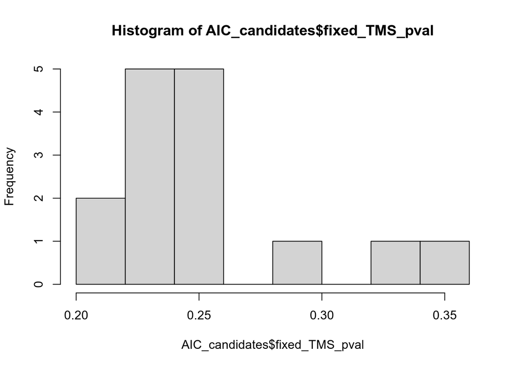

```r
hist(AIC_candidates$fixed_TMS_pval) # look at where the p-values are
```

Conclusion: no model supports fixed TMS effect.

4. Likelihood ratio test for the `(1|TMS_Type:participant_id)` random effect. If present in the model we will compare against a reduced model without it, and vice versa (introducing necessary component terms, per the inheritance principle).

```r
# formulas with TMS fixed effect
has_TMS <- grepl("TMS_Type ", AIC_candidates$formula, fixed = TRUE)

# formulas with participant random effect
has_participant <- grepl(
  "(1|participant_id)", AIC_candidates$formula,
  fixed = TRUE
)

# formulas with TMS x participant random effect
has_TMS_participant <- grepl(
  "(1|participant_id:TMS_Type)", AIC_candidates$formula,
  fixed = TRUE
)

AIC_candidates$TMS_participant_full <- AIC_candidates$formula

tmp <- paste0(AIC_candidates$TMS_participant_full, " + TMS_Type")
AIC_candidates$TMS_participant_full <- ifelse(
  has_TMS, AIC_candidates$TMS_participant_full, tmp
)

tmp <- paste0(AIC_candidates$TMS_participant_full, " + (1|participant_id)")
AIC_candidates$TMS_participant_full <- ifelse(
  has_participant, AIC_candidates$TMS_participant_full, tmp
)

tmp <- paste0(AIC_candidates$TMS_participant_full, " + (1|participant_id:TMS_Type)")
AIC_candidates$TMS_participant_full <- ifelse(
  has_TMS_participant, AIC_candidates$TMS_participant_full, tmp
)

AIC_candidates$TMS_participant_reduced <- str_remove_all(
  AIC_candidates$TMS_participant_full, fixed(" + (1|participant_id:TMS_Type)")
)

# AIC_candidates[,c("formula", "TMS_participant_full", "TMS_participant_reduced")] # double-check

# note that there are many duplicate model specifications in there
```

```r
AIC_candidates$TMS_participant_pval <- -1.0
for (i in seq_len(nrow(AIC_candidates))) {
  m_full <- glmer(
    AIC_candidates$TMS_participant_full[i],
    data = data,
    family = binomial
  )
  m_reduced <- glmer(
    AIC_candidates$TMS_participant_reduced[i],
    data = data,
    family = binomial
  )
  a <- anova(m_full, m_reduced)
  p_val <- a$"Pr(>Chisq)"[2]
  # print(p_val)
  AIC_candidates$TMS_participant_pval[i] <- p_val
}

AIC_candidates[AIC_candidates$TMS_participant_pval < 0.05, ]
```

```
## # A tibble: 0 × 9
## # ℹ 9 variables: formula <chr>, AIC <dbl>, BIC <dbl>, fixed_TMS_full <chr>,
## #   fixed_TMS_reduced <chr>, fixed_TMS_pval <dbl>, TMS_participant_full <chr>,
## #   TMS_participant_reduced <chr>, TMS_participant_pval <dbl>
```

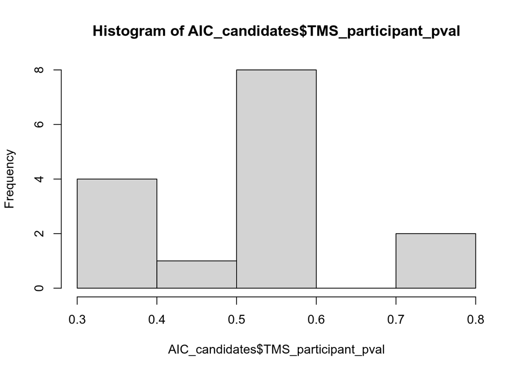

[output not shown]

```r
hist(AIC_candidates$TMS_participant_pval) # look at where the p-values are
```

5. Likelihood ratio test for the `(1|TMS_Type:problem_id)` random effect. If present in the model we will compare against a reduced model without it, and vice versa (introducing necessary component terms, per the inheritance principle).

```r
# formulas with TMS fixed effect
has_TMS <- grepl("TMS_Type ", AIC_candidates$formula, fixed = TRUE)

# formulas with problem random effect
has_problem <- grepl(
  "(1|problem_id)", AIC_candidates$formula,
  fixed = TRUE
)

# formulas with TMS x problem random effect
has_TMS_problem <- grepl(
  "(1|problem_id:TMS_Type)", AIC_candidates$formula,
  fixed = TRUE
)

AIC_candidates$TMS_problem_full <- AIC_candidates$formula

tmp <- paste0(AIC_candidates$TMS_problem_full, " + TMS_Type")
AIC_candidates$TMS_problem_full <- ifelse(
  has_TMS, AIC_candidates$TMS_problem_full, tmp
)

tmp <- paste0(AIC_candidates$TMS_problem_full, " + (1|problem_id)")
AIC_candidates$TMS_problem_full <- ifelse(
  has_problem, AIC_candidates$TMS_problem_full, tmp
)

tmp <- paste0(AIC_candidates$TMS_problem_full, " + (1|problem_id:TMS_Type)")
AIC_candidates$TMS_problem_full <- ifelse(
  has_TMS_problem, AIC_candidates$TMS_problem_full, tmp
)

AIC_candidates$TMS_problem_reduced <- str_remove_all(
  AIC_candidates$TMS_problem_full, fixed(" + (1|problem_id:TMS_Type)")
)

# AIC_candidates[,c("formula", "TMS_problem_full", "TMS_problem_reduced")] # double-check

# note that there are many duplicate model specifications in there
```

```r
AIC_candidates$TMS_problem_pval <- -1.0
for (i in seq_len(nrow(AIC_candidates))) {
  m_full <- glmer(
    AIC_candidates$TMS_problem_full[i],
    data = data,
    family = binomial
  )
  m_reduced <- glmer(
    AIC_candidates$TMS_problem_reduced[i],
    data = data,
    family = binomial
  )
  a <- anova(m_full, m_reduced)
  p_val <- a$"Pr(>Chisq)"[2]
  # print(p_val)
  AIC_candidates$TMS_problem_pval[i] <- p_val
}
```

[output not shown]

[output not shown]

```r
AIC_candidates[AIC_candidates$TMS_problem_pval < 0.05, ]
```

```
## # A tibble: 0 × 12
## # ℹ 12 variables: formula <chr>, AIC <dbl>, BIC <dbl>, fixed_TMS_full <chr>,
## #   fixed_TMS_reduced <chr>, fixed_TMS_pval <dbl>, TMS_participant_full <chr>,
## #   TMS_participant_reduced <chr>, TMS_participant_pval <dbl>,
## #   TMS_problem_full <chr>, TMS_problem_reduced <chr>, TMS_problem_pval <dbl>
```

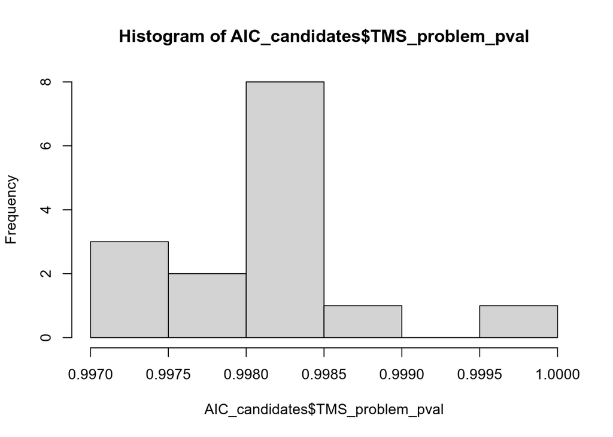

```r
hist(AIC_candidates$TMS_problem_pval) # look at where the p-values are
```